# Weather Data Downloads

davegoblue

5/20/2020

## Background

The file ‘AdditionalCoding_202003_v002.Rmd’ contains code for dowloading, processing, integrating, and analyzing historical weather data as contained in METAR archives.

METAR are hourly weather data collected at airports, including visibility, wind, temperature, dew point, precipitation, clouds, barometric pressure, and other features that may impact safe aviation.

Iowa State University has a great database of archived METAR data, stored in a manner that makes for easy, automated downloads in CSV format.

The objective of this file is to isolate the portions of code that download data from the Iowa State archives and run initial processing to verify data integrity and produce/save tibbles for further exploration.

#### *Example #1: Functions for Downloading METAR Data*

There are two key functions for downloading METAR data:

- genericGetASOSData() downloads METAR data from a specified station with a specified start and end date to a specified file location. Defaults are set as per Iowa State’s html code when requesting a CSV.
- getASOSStationTime() automates parameter management for calling genericGetASOSData(), with specific focus on converting a user’s desired station and time to a sensible filename, and converting target year to a sensible start and end time (METAR are in Zulu/UTC time zone, so it is helpful to start early and end late to have full data even if later converting to a local time zone)

The code for function genericGetASOSData:

```r
genericGetASOSData <- function(fileLoc,
                               stationID,
                               startDate,
                               endDate,
                               downloadMethod="curl",
                               baseURL="https://mesonet.agron.iastate.edu/cgi-bin/request/asos.py?",
                               dataFields="all",
                               dataTZ="Etc%2FUTC",
                               dataFormat="onlycomma",
                               dataLatLon="no",
                               dataMissing="M",
                               dataTrace="T",
                               dataDirect="no",
                               dataType=2
                               ) {

    # Get the year, day, and hour of the key dates
    y1 <- lubridate::year(startDate)
    m1 <- lubridate::month(startDate)
    d1 <- lubridate::day(startDate)

    y2 <- lubridate::year(endDate)
    m2 <- lubridate::month(endDate)
    d2 <- lubridate::day(endDate)

    # Mimic the string shown below
    # https://mesonet.agron.iastate.edu/cgi-bin/request/asos.py?station=LAS&data=all&year1=2015&month1=12&day1=31&year2=2017&month2=1&day2=2&tz=Etc%2FUTC&format=onlycomma&latlon=no&missing=M&trace=T&direct=no&report_type=2

    useURL <- paste0(baseURL, "station=", stationID)  # add the desired station
    useURL <- paste0(useURL, "&data=", dataFields)  # default is "all
    useURL <- paste0(useURL, "&year1=", y1, "&month1=", m1, "&day1=", d1)  # Specify start ymd
    useURL <- paste0(useURL, "&year2=", y2, "&month2=", m2, "&day2=", d2)  # Specify end ymd
    useURL <- paste0(useURL, "&tz=", dataTZ)  # time zone (default UTC)
    useURL <- paste0(useURL, "&format=", dataFormat)  # file format (default CSV)
    useURL <- paste0(useURL, "&latlon=", dataLatLon)  # Whether to include lat-lon (default no)
    useURL <- paste0(useURL, "&missing=", dataMissing)  # How to handle missing data (default is 'M')
    useURL <- paste0(useURL, "&trace=", dataTrace)  # How to handle trace data (default is 'T')
    useURL <- paste0(useURL, "&direct=", dataDirect)  # Whether to directly get the data (default is 'no')
    useURL <- paste0(useURL, "&report_type=", dataType)  # Whether to get just METAR (2, default)

    # Download the file
    cat("\nDownloading from:", useURL, "\nDownloading to:", fileLoc, "\n")
    download.file(useURL, destfile=fileLoc, method=downloadMethod)

    return(TRUE)
}
```

The code for getASOSStationTime:

```r
getASOSStationTime <- function(stationID,
                               startDate=NULL,
                               endDate=NULL,
                               analysisYears=NULL,
                               fileLoc=NULL,
                               ovrWrite=FALSE,
                               ...) {

    # Get the relevant time period for the data
    if (is.null(analysisYears) & (is.null(startDate) | is.null(endDate))) {
        stop("Must provide either analysisYears or both of startDate and endDate")
    }
    if (!is.null(startDate) & !is.null(endDate) & !is.null(analysisYears)) {
        stop("Should specify EITHER both of startDate and endDate OR analysisYears BUT NOT both")
    }
    if (is.null(startDate)) {
        startDate <- ISOdate(min(analysisYears)-1, 12, 31, hour=0)
        endDate <- ISOdate(max(analysisYears)+1, 1, 2, hour=0)
    }

    # Create the file name
    if (!is.null(analysisYears)) {
        if (length(analysisYears) == 1) { timeDesc <- analysisYears }
        else { timeDesc <- paste0(min(analysisYears), "-", max(analysisYears)) }
    } else {
        timeDesc <- paste0(lubridate::year(startDate),
                           stringr::str_pad(lubridate::month(startDate), 2, pad="0"),
                           stringr::str_pad(lubridate::day(startDate), 2, pad="0"),
                           "-",
                           lubridate::year(endDate),
                           stringr::str_pad(lubridate::month(endDate), 2, pad="0"),
                           stringr::str_pad(lubridate::day(endDate), 2, pad="0")
                           )
    }

    if (is.null(fileLoc)) {
        fileLoc <- paste0("./RInputFiles/",
                          "metar_k",
                          stringr::str_to_lower(stationID),
                          "_",
                          timeDesc,
                          ".txt"
                          )
    }

    cat("\nData for station", stationID, "from", as.character(startDate), "to",
        as.character(endDate), "will download to", fileLoc, "\n"
        )

    if (file.exists(fileLoc) & !ovrWrite) {
        stop("File already exists, aborting")
    }

    genericGetASOSData(fileLoc=fileLoc, stationID=stationID, startDate=startDate, endDate=endDate, ...)

}
```

Example downloads are created (cached to avoid multiple hits to Iowa State’s server), with focus on additional 2016 data for Wintry cities to build on the later analyses in ‘AdditionalCoding_202003_v002.Rmd’:

```r
# Download 2016 weather data for Milwaukee, WI
getASOSStationTime(stationID="MKE", analysisYears=2016, ovrWrite=TRUE)
```

```
##
## Data for station MKE from 2015-12-31 to 2017-01-02 will download to ./RInputFiles/metar_kmke_2016.txt
##
```

```
## [1] TRUE
```

```r
# Download 2016 weather data for Madison, WI
getASOSStationTime(stationID="MSN", analysisYears=2016, ovrWrite=TRUE)
```

```
##
## Data for station MSN from 2015-12-31 to 2017-01-02 will download to ./RInputFiles/metar_kmsn_2016.txt
##
```

```
## [1] TRUE
```

```r
# Download 2016 weather data for Green Bay, WI
getASOSStationTime(stationID="GRB", analysisYears=2016, ovrWrite=TRUE)
```

```
##
## Data for station GRB from 2015-12-31 to 2017-01-02 will download to ./RInputFiles/metar_kgrb_2016.txt
##
```

```
## [1] TRUE
```

```r
# Download 2016 weather data for Escanaba, MI
getASOSStationTime(stationID="ESC", analysisYears=2016, ovrWrite=TRUE)
```

```
##
## Data for station ESC from 2015-12-31 to 2017-01-02 will download to ./RInputFiles/metar_kesc_2016.txt
##
```

```
## [1] TRUE
```

```r
# Download 2016 weather data for Traverse City, MI
getASOSStationTime(stationID="TVC", analysisYears=2016, ovrWrite=TRUE)
```

```
##
## Data for station TVC from 2015-12-31 to 2017-01-02 will download to ./RInputFiles/metar_ktvc_2016.txt
##
```

```
## [1] TRUE
```

```r
# Download 2016 weather data for Grand Rapids, MI
getASOSStationTime(stationID="GRR", analysisYears=2016, ovrWrite=TRUE)
```

```
##
## Data for station GRR from 2015-12-31 to 2017-01-02 will download to ./RInputFiles/metar_kgrr_2016.txt
##
```

```
## [1] TRUE
```

```r
# Download 2016 weather data for Indianapolis, IN
getASOSStationTime(stationID="IND", analysisYears=2016, ovrWrite=TRUE)
```

```
##
## Data for station IND from 2015-12-31 to 2017-01-02 will download to ./RInputFiles/metar_kind_2016.txt
##
```

```
## [1] TRUE
```

Confirmation can be obtained that the files downloaded as expected:

```r
for (airport in c("kmke", "kmsn", "kgrb", "kesc", "ktvc", "kgrr", "kind")) {

    fileCheck <- paste0("./RInputFiles/metar_", airport, "_2016.txt")
    print(file.info(fileCheck)[c("size", "isdir", "mode", "mtime")])

}
```

```
##                                      size isdir mode               mtime
## ./RInputFiles/metar_kmke_2016.txt 2266640 FALSE  666 2020-05-20 08:49:35
##                                      size isdir mode               mtime
## ./RInputFiles/metar_kmsn_2016.txt 2365211 FALSE  666 2020-05-20 08:58:48
##                                      size isdir mode               mtime
## ./RInputFiles/metar_kgrb_2016.txt 2315233 FALSE  666 2020-05-20 08:57:21
##                                      size isdir mode               mtime
## ./RInputFiles/metar_kesc_2016.txt 2787036 FALSE  666 2020-05-20 09:09:20
##                                      size isdir mode               mtime
## ./RInputFiles/metar_ktvc_2016.txt 2390181 FALSE  666 2020-05-20 08:57:28
##                                      size isdir mode               mtime
## ./RInputFiles/metar_kgrr_2016.txt 2407973 FALSE  666 2020-05-20 08:57:32
##                                      size isdir mode               mtime
## ./RInputFiles/metar_kind_2016.txt 2262460 FALSE  666 2020-05-20 08:57:46
```

The files are all in the 2-3 MB range, which is appropriate for a year of METAR data.

#### *Example #2: Finding the Hourly Reporting Time for METAR Data*

The METAR are downloaded in raw CSV format, and require some data wrangling to extract a clean file in a common format.

One component of wrangling a METAR file is to specify the columns and expected data types. The Iowa State data are contained in the below format, which is not necessarily standard to how other archives may store the information (Iowa State has run processing on the METAR file):

```r
metType <- readr::cols(station=readr::col_character(),
                       valid=readr::col_datetime(),
                       tmpf=readr::col_double(),
                       dwpf=readr::col_double(),
                       relh=readr::col_double(),
                       drct=readr::col_double(),
                       sknt=readr::col_double(),
                       p01i=readr::col_character(),  # needs to handle 'T' for trace
                       alti=readr::col_double(),
                       mslp=readr::col_double(),
                       vsby=readr::col_double(),
                       gust=readr::col_double(),
                       skyc1=readr::col_character(),
                       skyc2=readr::col_character(),
                       skyc3=readr::col_character(),
                       skyc4=readr::col_character(),
                       skyl1=readr::col_double(),
                       skyl2=readr::col_double(),
                       skyl3=readr::col_double(),
                       skyl4=readr::col_double(),
                       wxcodes=readr::col_character(),
                       ice_accretion_1hr=readr::col_character(), # needs to handle 'T' for trace
                       ice_accretion_3hr=readr::col_character(), # needs to handle 'T' for trace
                       ice_accretion_6hr=readr::col_character(), # needs to handle 'T' for trace
                       peak_wind_gust=readr::col_double(),
                       peak_wind_drct=readr::col_double(),
                       peak_wind_time=readr::col_datetime(),
                       feel=readr::col_double(),
                       metar=readr::col_character()
                       )
```

Another component of wrangling a METAR file is to extract the hourly observations. Since the primary use of a METAR is aviation safety, non-hourly updates are common when changes in clouds, winds, precipiation, and the like need to be communicated. For analysis, though, it is more useful to have just the hourly summaries which contain the most salient information about the last hour in an easily digestable format.

Each airport reports hourly at the same number of minutes past the hour (each airport may have a different hourly reporting time, but the hourly reporting time for a given airport is constant all year). In the US, this is commonly some time between 50-55 minutes past the hour.

The function findHourlyReportingTime() reads a METAR file and analyzes the most commonly occuring time:

```r
findHourlyReportingTimes <- function(metFile=NULL,
                                     metStation=NULL,
                                     metTime=NULL,
                                     metPath="./RInputFiles/metar_k",
                                     metSep="_",
                                     metExt=".txt",
                                     stationToLower=TRUE,
                                     returnAll=FALSE,
                                     naValues=c("", "NA", "M"),
                                     colTypes=metType,
                                     threshError=0
                                     ) {

    # Find the file name if it has not been passed
    if (is.null(metFile)) {
        if (is.null(metStation) | is.null(metPath) | is.null(metSep) | is.null(metTime) | is.null(metExt)) {
            stop("If metFile is not passed, all other parameters must be passed so filename can be created")
        }
        if (stationToLower) { metStation <- stringr::str_to_lower(metStation) }
        metFile <- paste0(metPath, metStation, metSep, metTime, metExt)
    }

    # Find the most common Zulu time (this will be the METAR)
    zTimes <- readr::read_csv(metFile, na=naValues, col_types=colTypes) %>%
        pull(metar) %>%
        stringr::str_match(pattern="\\d{2}Z") %>%
        as.vector() %>%
        table() %>%
        sort(decreasing=TRUE)

    # Print the most common 10 times
    cat("\nMost common 10 times for file:", metFile, "\n")
    print(zTimes[1:10])

    # Print the estimated Zulu time
    cat("\nThe most common Zulu time for", metFile, "is", names(zTimes)[1], "\nFrequency is",
        round(100*zTimes[1]/sum(zTimes), 1), "% (", zTimes[1], "of", sum(zTimes), ")\n"
        )

    # STOP if the file has less than threshError observations at its main point
    if (zTimes[1] / sum(zTimes) < threshError) {
        cat("\nThe following routines depend on a single, hourly METAR\n")
        cat("This file may not have that feature; investigate and fix\n")
        stop(paste0("Most frequent time occurs less than threshError: ", threshError))
    }

    # Return the fill vector if requested (likely only if a problem is detected), otherwise return the time
    if (returnAll) {
        return(zTimes)
    } else {
        return(names(zTimes)[1])
    }

}

# The tidvverse library is needed for the remainder of the process
library(tidyverse)
# The most common hours are assessed
findHourlyReportingTimes(metStation="MKE", metTime=2016)
```

```
##
## Most common 10 times for file: ./RInputFiles/metar_kmke_2016.txt
## .
##  52Z  59Z  33Z  16Z  29Z  09Z  48Z  39Z  44Z  14Z
## 8808   55   54   50   47   46   44   43   43   42
##
## The most common Zulu time for ./RInputFiles/metar_kmke_2016.txt is 52Z
## Frequency is 83.3 % ( 8808 of 10573 )
```

```
## [1] "52Z"
```

```r
findHourlyReportingTimes(metStation="MSN", metTime=2016)
```

```
##
## Most common 10 times for file: ./RInputFiles/metar_kmsn_2016.txt
## .
##  53Z  22Z  06Z  28Z  38Z  49Z  23Z  04Z  12Z  32Z
## 8798   60   58   57   55   55   53   52   52   52
##
## The most common Zulu time for ./RInputFiles/metar_kmsn_2016.txt is 53Z
## Frequency is 79 % ( 8798 of 11136 )
```

```
## [1] "53Z"
```

```r
findHourlyReportingTimes(metStation="GRB", metTime=2016)
```

```
##
## Most common 10 times for file: ./RInputFiles/metar_kgrb_2016.txt
## .
##  53Z  02Z  33Z  00Z  03Z  17Z  18Z  27Z  16Z  51Z
## 8803   64   64   63   62   58   57   57   55   55
##
## The most common Zulu time for ./RInputFiles/metar_kgrb_2016.txt is 53Z
## Frequency is 77.8 % ( 8803 of 11309 )
```

```
## [1] "53Z"
```

```r
findHourlyReportingTimes(metStation="ESC", metTime=2016)
```

```
##
## Most common 10 times for file: ./RInputFiles/metar_kesc_2016.txt
## .
##  55Z  56Z  35Z  15Z  13Z  52Z  08Z  22Z  43Z  46Z
## 3512 3420 3196 3171   44   43   41   41   41   40
##
## The most common Zulu time for ./RInputFiles/metar_kesc_2016.txt is 55Z
## Frequency is 23.8 % ( 3512 of 14787 )
```

```
## [1] "55Z"
```

```r
findHourlyReportingTimes(metStation="TVC", metTime=2016)
```

```
##
## Most common 10 times for file: ./RInputFiles/metar_ktvc_2016.txt
## .
##  53Z  07Z  39Z  49Z  46Z  23Z  17Z  32Z  08Z  35Z
## 8814   63   62   62   60   58   56   54   53   53
##
## The most common Zulu time for ./RInputFiles/metar_ktvc_2016.txt is 53Z
## Frequency is 78.7 % ( 8814 of 11196 )
```

```
## [1] "53Z"
```

```r
findHourlyReportingTimes(metStation="GRR", metTime=2016)
```

```
##
## Most common 10 times for file: ./RInputFiles/metar_kgrr_2016.txt
## .
##  53Z  42Z  41Z  08Z  21Z  22Z  23Z  34Z  38Z  31Z
## 8812   64   63   60   59   55   55   54   54   52
##
## The most common Zulu time for ./RInputFiles/metar_kgrr_2016.txt is 53Z
## Frequency is 79.2 % ( 8812 of 11126 )
```

```
## [1] "53Z"
```

```r
findHourlyReportingTimes(metStation="IND", metTime=2016)
```

```
##
## Most common 10 times for file: ./RInputFiles/metar_kind_2016.txt
## .
##  54Z  49Z  43Z  51Z  36Z  01Z  44Z  22Z  14Z  19Z
## 8767   55   54   47   45   43   42   41   40   39
##
## The most common Zulu time for ./RInputFiles/metar_kind_2016.txt is 54Z
## Frequency is 83.4 % ( 8767 of 10513 )
```

```
## [1] "54Z"
```

With the exception of Escanaba, MI (ESC), the most common times seeem reasonable - greater than 75% of the observations are at a specific, recurring time past the hour in the early-mid 50s:

- 52Z - Milwaukee (83%)
- 53Z - Madison (79%), Green Bay (78%), Traverse City (79%), Grand Rapids (79%)
- 54Z - Indianapolis (83%)

Escanaba appears to have multiple reporting times, which may be driven by Escanaba being a much smaller airport that sees little if any scheduled air service. As there are sufficient Wintry cities already for further analysis, and as Green Bay is less than 100 miles to the south, Escanaba will be excluded from any follow-on analysis.

The remaining 6 cities all have roughly 8,800 observations at the most common time. There are 8,784 hours in a 366-day leap-year (2016), 1-2 extra days were pulled on either side of the year, an observation is expected every hour, and these are real-world systems where occasional missing archive data is not unexpected. So, to a first order, data quantities of about 8,800 observations appear accurate.

#### *Example #3: Processing a METAR File*

The METAR files can be processed, with data extracted based on the hourly time identified above. The two key fields in the files are:

- valid - the UTC date-time associated to the METAR
- metar - the raw METAR data

The other fields represent processed data which may be useful for other purposes. But, the main purpose of this analysis is to extract and analyze METAR data.

Broadly speaking, there are several steps required to convert downloaded data for use in further analysis:

- readMETAR() - extract only hourly observations, check for expected times and record uniqueness
- initialParseMETAR() - parse the raw METAR data based on an expected regex pattern
- convertMETAR() - converts characters from the parsed METAR file to meaningful numbers for analysis
- fixMETAR() - corrects for issues with extracting and converting visibility, wind gusts, and SLP
- getclouds() - extract cloud data from the METAR and determine cloud types, minimum heights, and minimum ceilings
- bindMETAR() - put everything together for further analysis

The readMETAR() function is designed to extract only the hourly observations. It also checks that all of the expected times are found in the data and flags any differences. If any unexpected times are found in the data, or if any of the data are not unique, an error is thrown:

```r
# Function to make an initial read of the data, filter to METAR records, and check date-times
readMETAR <- function(fileName,
                      timeZ,
                      expMin,
                      expDays,
                      colTypes=NULL,
                      printSTR=FALSE,
                      errUnexpected=TRUE,
                      errNonUnique=TRUE,
                      logFile=""
                      ) {

    # Read METAR data
    initRead <- readr::read_csv(fileName, na=c("", "NA", "M"), col_types=colTypes)

    # Provide descriptions of the METAR read (str only if flag is set)
    if (printSTR) {
        print(str(initRead, give.attr=FALSE))
        print(dim(initRead))
    }

    # Filter to only data that ends with times ending in timeZ
    filterRead <- initRead %>%
        filter(str_detect(metar, timeZ))
    if (printSTR) { print(dim(filterRead)) }

    # Check that the dates and times included are as expected
    expDate <- expMin + lubridate::hours(0:(24*expDays - 1))

    # Observations expected but not recorded
    expNotRecorded <- as.POSIXct(setdiff(expDate, filterRead$valid), origin="1970-01-01", tz="UTC")

    # Print summary to the main log file
    cat("\n*** OBSERVATIONS EXPECTED BUT NOT RECORDED:", length(expNotRecorded), "***\n")

    # Cat details to the provided logFile (if logFile="", these go the main log file)
    cat("\n*** OBSERVATIONS EXPECTED BUT NOT RECORDED: ***\n",
        paste0("\n", paste0(format(expNotRecorded, "%Y-%m-%d %H:%M:%S", usetz=TRUE), collapse="\n")),
        file=logFile,
        append=TRUE
        )


    # Observations recorded but not expected
    unexpected <- as.POSIXct(setdiff(filterRead$valid, expDate), origin="1970-01-01", tz="UTC")

    # Summary to the main log filr
    cat("\n\n*** OBSERVATIONS RECORDED BUT NOT EXPECTED:", length(unexpected), "***\n")

    # Cat details to the provided logFile (if logFile="", these go to the main log file)
    if (length(unexpected) > 0) {
        cat("\n*** OBSERVATIONS RECORDED BUT NOT EXPECTED: ***\n",
            paste0(format(unexpected, "%Y-%m-%d %H:%M:%S", usetz=TRUE), collapse="\n"),
            file=logFile,
            append=TRUE
            )
    }
    if (errUnexpected) {
        stopifnot(length(unexpected)==0)
    }

    # Confirmation of uniqueness
    allUnique <- length(unique(filterRead$valid)) == length(filterRead$valid)

    # Send these to the main log file
    cat("\n*** Are the extracted records unique? ***\n", allUnique, "\n\n")
    if (errNonUnique) {
        stopifnot(allUnique)
    }

    # Return the dataset as a tibble
    tibble::as_tibble(filterRead)
}
```

As an example, readMETAR() is run for the Green Bay data:

```r
readGRB <- readMETAR("./RInputFiles/metar_kgrb_2016.txt",
                     timeZ="53Z",
                     expMin=as.POSIXct("2015-12-31 00:53:00", tz="UTC"),
                     expDays=368,
                     colTypes=metType
                     )
```

```
##
## *** OBSERVATIONS EXPECTED BUT NOT RECORDED: 29 ***
##
## *** OBSERVATIONS EXPECTED BUT NOT RECORDED: ***
##
## 2016-01-06 04:53:00 UTC
## 2016-01-19 19:53:00 UTC
## 2016-01-26 07:53:00 UTC
## 2016-03-09 09:53:00 UTC
## 2016-05-06 11:53:00 UTC
## 2016-05-06 12:53:00 UTC
## 2016-05-11 08:53:00 UTC
## 2016-05-28 04:53:00 UTC
## 2016-06-17 23:53:00 UTC
## 2016-06-18 00:53:00 UTC
## 2016-06-28 12:53:00 UTC
## 2016-07-13 14:53:00 UTC
## 2016-07-13 15:53:00 UTC
## 2016-07-13 16:53:00 UTC
## 2016-07-13 17:53:00 UTC
## 2016-08-05 07:53:00 UTC
## 2016-08-31 16:53:00 UTC
## 2016-09-28 12:53:00 UTC
## 2016-10-25 01:53:00 UTC
## 2016-11-03 21:53:00 UTC
## 2016-11-15 06:53:00 UTC
## 2016-11-15 07:53:00 UTC
## 2016-11-21 00:53:00 UTC
## 2016-11-24 12:53:00 UTC
## 2016-12-03 06:53:00 UTC
## 2016-12-03 09:53:00 UTC
## 2016-12-13 18:53:00 UTC
## 2016-12-16 08:53:00 UTC
## 2016-12-16 17:53:00 UTC
##
## *** OBSERVATIONS RECORDED BUT NOT EXPECTED: 0 ***
##
## *** Are the extracted records unique? ***
##  TRUE
```

```r
str(readGRB, give.attr=FALSE)
```

```
## Classes 'tbl_df', 'tbl' and 'data.frame':    8803 obs. of  29 variables:
##  $ station          : chr  "GRB" "GRB" "GRB" "GRB" ...
##  $ valid            : POSIXct, format: "2015-12-31 00:53:00" "2015-12-31 01:53:00" ...
##  $ tmpf             : num  28 27 27 28 27 ...
##  $ dwpf             : num  21.9 21.9 21.9 21 21 ...
##  $ relh             : num  77.5 81 81 74.6 78 ...
##  $ drct             : num  240 280 260 250 250 260 250 250 250 250 ...
##  $ sknt             : num  4 5 5 6 6 7 9 9 10 9 ...
##  $ p01i             : chr  "0.00" "0.00" "0.00" "0.00" ...
##  $ alti             : num  30.1 30.1 30.1 30.1 30.1 ...
##  $ mslp             : num  1022 1022 1022 1022 1022 ...
##  $ vsby             : num  10 10 10 10 10 10 10 10 10 10 ...
##  $ gust             : num  NA NA NA NA NA NA NA NA NA NA ...
##  $ skyc1            : chr  "OVC" "OVC" "OVC" "OVC" ...
##  $ skyc2            : chr  NA NA NA NA ...
##  $ skyc3            : chr  NA NA NA NA ...
##  $ skyc4            : chr  NA NA NA NA ...
##  $ skyl1            : num  2400 2300 2300 2200 2400 2500 2500 2700 2700 2600 ...
##  $ skyl2            : num  NA NA NA NA NA NA NA NA NA NA ...
##  $ skyl3            : num  NA NA NA NA NA NA NA NA NA NA ...
##  $ skyl4            : num  NA NA NA NA NA NA NA NA NA NA ...
##  $ wxcodes          : chr  NA NA NA NA ...
##  $ ice_accretion_1hr: chr  NA NA NA NA ...
##  $ ice_accretion_3hr: chr  NA NA NA NA ...
##  $ ice_accretion_6hr: chr  NA NA NA NA ...
##  $ peak_wind_gust   : num  NA NA NA NA NA NA NA NA NA NA ...
##  $ peak_wind_drct   : num  NA NA NA NA NA NA NA NA NA NA ...
##  $ peak_wind_time   : POSIXct, format: NA NA ...
##  $ feel             : num  22.8 20.4 20.4 20.8 19.5 ...
##  $ metar            : chr  "KGRB 310053Z 24004KT 10SM OVC024 M02/M06 A3014 RMK AO2 SLP217 T10221056" "KGRB 310153Z 28005KT 10SM OVC023 M03/M06 A3014 RMK AO2 SLP217 T10281056" "KGRB 310253Z 26005KT 10SM OVC023 M03/M06 A3013 RMK AO2 SLP215 T10281056 50000" "KGRB 310353Z 25006KT 10SM OVC022 M02/M06 …
```

The initialParseMETAR() function is designed to parse a METAR file based on an expected regex string. The regex passed is specific to the parameters of interest for this project; different regex could be passed if different portions of the METAR were desired to be extracted:

```r
# Code for the initial METAR parsing
initialParseMETAR <- function(met,
                              val,
                              labs,
                              showParseSummary=FALSE,
                              glimpseFinal=FALSE,
                              logFile=""
                              ) {

    # Pull the METAR data
    metAll <- met %>%
        pull(metar)

    # Find the number of matching elements
    matchSummary <- str_detect(metAll, pattern=val) %>%
        table()

    # Print this to the main log file
    cat("\n*** Tentative Summary of Element Parsing *** \n")
    print(matchSummary)

    # The strings that do not match have errors in the raw data (typically, missing wind speed)
    mismatchData <- metAll[!str_detect(metAll, pattern=val)]

    # Print the to the logFile (if logFile="", then these print to the main log file)
    cat("\n*** Data Not Matched:", length(mismatchData),"*** \n",
        paste0("\n", paste0(mismatchData, collapse="\n"), "\n"),
        file=logFile,
        append=TRUE
        )


    # A matrix of string matches can be obtained
    mtxParse <- str_match(metAll, pattern=val)
    if (showParseSummary) {
        cat("\n*** Parsing matrix summary *** \n")
        print(dim(mtxParse))
        print(head(mtxParse))
    }

    # Create a data frame
    dfParse <- data.frame(mtxParse, stringsAsFactors=FALSE) %>%
        mutate(dtime=met$valid, origMETAR=met$metar)
    names(dfParse) <- c(labs, "dtime", "origMETAR")
    dfParse <- tibble::as_tibble(dfParse)
    if (glimpseFinal) {
        cat("\n*** Summary of the parsed data *** \n")
        glimpse(dfParse)
    }

    dfParse
}
```

The function can then be run against the Green Bay data:

```r
# Create a search string for METAR
valMet <- "53Z.*?(VRB|\\d{3})(\\d{2})(G\\d{2})?KT(.*?)(\\d{1,2}SM).*?\\s(M?\\d{2})/(M?\\d{2}).*?(A\\d{4}).*?RMK.*?(SLP\\d{3}).*?(T\\d{8})"

# Create the names for the search string to parse in to
labsMet <- c("METAR", "WindDir", "WindSpeed", "WindGust", "Dummy", "Visibility",
             "TempC", "DewC", "Altimeter", "SLP", "FahrC"
             )

# Run the METAR parsing on the raw data
initGRB <- initialParseMETAR(readGRB, val=valMet, labs=labsMet, glimpseFinal=TRUE)
```

```
##
## *** Tentative Summary of Element Parsing ***
## .
## FALSE  TRUE
##    62  8741
##
## *** Data Not Matched: 62 ***
##
## KGRB 122053Z 18006KT 10SM CLR 17/09 A3003
## KGRB 281853Z 10SM CLR 11/M01 A3009 RMK AO2 SLP193 T01061006
## KGRB 021853Z 10SM -RA CLR 17/00 A3007 RMK AO2 RAB38 SLP185 P0000 T01720000 $
## KGRB 181653Z 10SM CLR 16/M03 A3029 RMK AO2 SLP260 T01561028 PWINO PNO $
## KGRB 191953Z 10SM FEW085 22/01 A3014 RMK AO2 SLP207 T02220011 PNO $
## KGRB 211953Z 10SM CLR 26/02 A3010 RMK AO2 SLP192 T02560017 PNO $
## KGRB 131153Z 10SM VCTS OVC050 14/08 A3015 RMK AO2 LTG DSNT W AND NW PRESRR SLP209 T01390078 10150 20139 51019 PNO $
## KGRB 181553Z 10SM CLR 28/17 A3023 RMK AO2 SLP233 T02780167 PNO $
## KGRB 270653Z AUTO 24004KT 10SM CLR A2992 RMK AO2 SLPNO PWINO PNO $
## KGRB 270753Z AUTO 24005KT 10SM CLR A2992 RMK AO2 SLPNO PWINO PNO $
## KGRB 270853Z AUTO 25006KT 10SM CLR A2992 RMK AO2 SLPNO 51001 PWINO PNO $
## KGRB 270953Z AUTO 24006KT 10SM CLR A2993 RMK AO2 SLPNO PWINO PNO $
## KGRB 271053Z 26009KT 10SM CLR A2994 RMK AO2 SLPNO PNO $
## KGRB 271153Z 29010KT 10SM CLR A2995 RMK AO2 SLPNO 52010 PNO $
## KGRB 271253Z 28009KT 10SM CLR A2997 RMK AO2 SLPNO PNO $
## KGRB 271853Z 32010KT 10SM FEW043 OVC050 23/14 A3003 RMK AO2 SLPNO T02280139 $
## KGRB 271953Z 30008KT 10SM OVC055 24/14 A3003 RMK AO2 SLPNO T02390139 $
## KGRB 272053Z 31010KT 10SM OVC060 23/14 A3004 RMK AO2 SLPNO T02280139 51007 $
## KGRB 272153Z 30009KT 10SM OVC060 22/13 A3004 RMK AO2 SLPNO T02220133 $
## KGRB 272253Z 31007KT 10SM OVC065 22/14 A3004 RMK AO2 SLPNO T02220139 $
## KGRB 272353Z 01014KT 10SM BKN040 BKN047 OVC070 19/14 A3006 RMK AO2 WSHFT 2332 SLPNO T01940144 10244 20194 51007 $
## KGRB 280053Z 34009G16KT 10SM BKN055 OVC070 19/13 A3008 RMK AO2 SLPNO T01890133 $
## KGRB 291353Z 10SM CLR 19/09 A3014 RMK AO2 SLP206 T01890094
## KGRB 291753Z 10SM SCT050 25/11 A3009 RMK AO2 SLP190 T02500111 10250 20150 58013
## KGRB 070253Z 10SM FEW047 BKN055 23/21 A2981 RMK AO2 SLP092 T02330206 53010
## KGRB 131253Z 10SM CLR 24/21 A2982 RMK AO2 SLP094 T02390211 $
## KGRB 141453Z 26014G23KT BKN033 22/15 A2975 RMK AO2 SLP071 60000 T02220150 51012 RVRNO $
## KGRB 171353Z 15009KT 7SM -RA FEW013 BKN060 OVC085 17/ A2987 RMK AO2 TSB05E20 SLP114 P0017 T0172 $
## KGRB 171453Z 17012G19KT 10SM BKN012 OVC024 18/ A2984 RMK AO2 RAE32 SLP102 P0004 60034 T0183 58030 $
## KGRB 171753Z 10SM -RA BKN021 23/23 A2984 RMK AO2 RAB07 SLP102 P0000 60034 T02330228 10233 20167 51012 $
## KGRB 171853Z 10SM BKN021 24/20 A2986 RMK AO2 RAE1757 SLP109 P0000 T02390200 $
## KGRB 182153Z 10SM FEW050 28/19 A3012 RMK AO2 SLP195 T02780189
```

[output cut: 32 more lines]

```
## Observations: 8,803
## Variables: 13
## $ METAR      <chr> "53Z 24004KT 10SM OVC024 M02/M06 A3014 RMK AO2 SLP217 T1...
## $ WindDir    <chr> "240", "280", "260", "250", "250", "260", "250", "250", ...
## $ WindSpeed  <chr> "04", "05", "05", "06", "06", "07", "09", "09", "10", "0...
## $ WindGust   <chr> NA, NA, NA, NA, NA, NA, NA, NA, NA, NA, NA, NA, NA, NA, ...
## $ Dummy      <chr> " ", " ", " ", " ", " ", " ", " ", " ", " ", " ", " ", "...
## $ Visibility <chr> "10SM", "10SM", "10SM", "10SM", "10SM", "10SM", "10SM", ...
## $ TempC      <chr> "M02", "M03", "M03", "M02", "M03", "M03", "M03", "M03", ...
## $ DewC       <chr> "M06", "M06", "M06", "M06", "M06", "M06", "M06", "M06", ...
## $ Altimeter  <chr> "A3014", "A3014", "A3013", "A3014", "A3014", "A3014", "A...
## $ SLP        <chr> "SLP217", "SLP217", "SLP215", "SLP217", "SLP217", "SLP21...
## $ FahrC      <chr> "T10221056", "T10281056", "T10281056", "T10221061", "T10...
## $ dtime      <dttm> 2015-12-31 00:53:00, 2015-12-31 01:53:00, 2015-12-31 02...
## $ origMETAR  <chr> "KGRB 310053Z 24004KT 10SM OVC024 M02/M06 A3014 RMK AO2 ...
```

The convertMETAR() function is designed to convert the parsed data to numeric entries for further analysis. Among the steps are:

- WindSpeed - convert from character to numeric
- WindGust - convert from character to numeric
- Visibility - remove ‘SM’ and convert remainder to numeric
- TempC - change ‘M’ (means negative) to ‘-’ and convert to numeric
- DewC - change ‘M’ (means negative) to ‘-’ and convert to numeric
- Altimeter - remove ‘A’ and convert remainder to numeric
- SLP - remove ‘SLP’ and convert remainder to numeric
- TempF - take characters 2-5 of T(dddd)dddd, convert to -ddd if leading d is 1, convert to numeric, divide by 10, multiply by 1.8 and add 32
- DewF - take characters 6-9 of Tdddd(dddd), convert to -ddd if leading d is 1, convert to numeric, divide by 10, multiply by 1.8 and add 32

Function code below:

```r
# Code for the conversion of METAR to meaningful numeric
# Function is hard-coded to work on metrics passed as default; potentially generalize later
convertMETAR <- function(met,
                         metrics=c("WindDir", "WindSpeed", "WindGust", "Visibility", "TempC",
                                   "DewC", "Altimeter", "SLP", "TempF", "DewF"
                                   ),
                         seed=2003211416,
                         showInvestigate=FALSE,
                         showNACounts=TRUE,
                         showMetricPlots=FALSE

                         ) {

    # Convert to numeric where appropriate
    dfParse <- met %>%
        mutate(WindSpeed = as.integer(WindSpeed),
               WindGust = as.numeric(WindGust),
               Visibility = as.numeric(str_replace(Visibility, "SM", "")),
               TempC = as.integer(str_replace(TempC, "M", "-")),
               DewC = as.integer(str_replace(DewC, "M", "-")),
               Altimeter = as.integer(str_replace(Altimeter, "A", "")),
               SLP = as.integer(str_replace(SLP, "SLP", "")),
               TempF = 32 + 1.8 * as.integer(str_replace(str_sub(FahrC, 2, 5), pattern="^1", "-"))/10,
               DewF = 32 + 1.8 * as.integer(str_replace(str_sub(FahrC, 6, 9), pattern="^1", "-"))/10
               )

    # Investigate the data
    if (showInvestigate) {
        cat("\n *** Parsed data structure, head, tail, and random sample *** \n")
        str(dfParse)
        print(head(dfParse))
        print(tail(dfParse))
        set.seed(seed)
        dfParse %>%
            sample_n(20) %>%
            print()
    }

    if (showNACounts) {
        # Check for NA values
        cat("\n *** Number of NA values *** \n")
        print(colSums(is.na(dfParse)))
    }

    # Plot of counts by key metric
    # NOTE - function has NOT YET been created in this module - placeholder
    if (showMetricPlots) {
        plotcountsByMetric(dfParse, mets=metrics)
    }

    # Return the parsed dataset
    dfParse

}
```

The function is run for the initial Green Bay data:

```r
convGRB <- convertMETAR(initGRB)
```

```
##
##  *** Number of NA values ***
##      METAR    WindDir  WindSpeed   WindGust      Dummy Visibility      TempC
##         62         62         62       8803         62         62         62
##       DewC  Altimeter        SLP      FahrC      dtime  origMETAR      TempF
##         62         62         62         62          0          0         62
##       DewF
##         62
```

```r
glimpse(convGRB)
```

```
## Observations: 8,803
## Variables: 15
## $ METAR      <chr> "53Z 24004KT 10SM OVC024 M02/M06 A3014 RMK AO2 SLP217 T1...
## $ WindDir    <chr> "240", "280", "260", "250", "250", "260", "250", "250", ...
## $ WindSpeed  <int> 4, 5, 5, 6, 6, 7, 9, 9, 10, 9, 11, 11, 11, 11, 8, 12, 13...
## $ WindGust   <dbl> NA, NA, NA, NA, NA, NA, NA, NA, NA, NA, NA, NA, NA, NA, ...
## $ Dummy      <chr> " ", " ", " ", " ", " ", " ", " ", " ", " ", " ", " ", "...
## $ Visibility <dbl> 10, 10, 10, 10, 10, 10, 10, 10, 10, 10, 10, 10, 10, 10, ...
## $ TempC      <int> -2, -3, -3, -2, -3, -3, -3, -3, -3, -4, -4, -4, -4, -5, ...
## $ DewC       <int> -6, -6, -6, -6, -6, -6, -6, -6, -6, -6, -7, -7, -8, -9, ...
## $ Altimeter  <int> 3014, 3014, 3013, 3014, 3014, 3014, 3013, 3014, 3015, 30...
## $ SLP        <int> 217, 217, 215, 217, 217, 216, 215, 216, 222, 221, 221, 2...
## $ FahrC      <chr> "T10221056", "T10281056", "T10281056", "T10221061", "T10...
## $ dtime      <dttm> 2015-12-31 00:53:00, 2015-12-31 01:53:00, 2015-12-31 02...
## $ origMETAR  <chr> "KGRB 310053Z 24004KT 10SM OVC024 M02/M06 A3014 RMK AO2 ...
## $ TempF      <dbl> 28.04, 26.96, 26.96, 28.04, 26.96, 26.96, 26.96, 26.06, ...
## $ DewF       <dbl> 21.92, 21.92, 21.92, 21.02, 21.02, 21.02, 21.02, 21.02, ...
```

There are then three fixes required to the converted data:

The function fixMETAR() runs the functions getVisibility(), getWindGusts(), and fixSLP(), and integrated the updates in a consolidated file:

```r
# Address the visibility issues
getVisibility <- function(curMet, origMet, var="metar", useNAforIncomplete=FALSE) {

    # Get the original METAR data
    metAll <- origMet %>%
        pull(var)

    # Correct for visibility
    # Areas that have \\d \\d/\\dSM
    sm1 <- which(str_detect(metAll, pattern=" \\d/\\dSM"))
    sm2 <- which(str_detect(metAll, pattern=" \\d \\d/\\dSM"))

    valSM1 <- str_match(metAll, pattern="\\d/\\dSM")[sm1]
    valSM1 <- str_replace(valSM1, "SM", "")
    valSM1 <- as.integer(str_sub(valSM1, 1, 1)) / as.integer(str_sub(valSM1, 3, 3))

    valSM2 <- str_match(metAll, pattern=" \\d \\d/\\dSM")[sm2]
    valSM2 <- as.integer(str_sub(valSM2, 2, 2))

    curMet[sm1, "Visibility"] <- valSM1
    curMet[sm2, "Visibility"] <- curMet[sm2, "Visibility"] + valSM2

    # Reset to NA if the original METAR is NA and useNAForIncomplete=TRUE
    if (useNAforIncomplete) {
        curMet[is.na(curMet$METAR), "Visibility"] <- NA
    }

    visCounts <- curMet %>%
        count(Visibility)
    visVector <- visCounts$n
    names(visVector) <- visCounts$Visibility
    cat("\nVisibilities after correcting for fractions:\n")
    print(visVector)
    cat("\n")

    curMet
}

# Correct for wind gusts
getWindGusts <- function(curMet, origMet, var="metar", useNAforIncomplete=FALSE) {

    metAll <- origMet %>%
        pull(var)

    gustCheck <- which(str_detect(metAll, pattern="\\d{5}G\\d{2}KT"))
    valGust <- str_match(metAll, pattern="\\d{5}G\\d{2}KT")[gustCheck]
    valGust <- as.integer(str_sub(valGust, 7, 8))

    curMet[gustCheck, "WindGust"] <- valGust

    # Reset to NA if the original METAR is NA and useNAForIncomplete=TRUE
    if (useNAforIncomplete) {
        curMet[is.na(curMet$METAR), "WindGust"] <- NA
    }

    gustCounts <- curMet %>%
        count(WindGust)
    gustVector <- gustCounts$n
    names(gustVector) <- gustCounts$WindGust

    cat("\nCounts of wind gusts extracted:\n")
    print(gustVector)
    cat("\n")

    curMet
}

# Correct for SLP
fixSLP <- function(curMet, showSLPGraph=TRUE) {

    dfParse <- curMet %>%
        mutate(modSLP=ifelse(curMet$SLP < 500, 1000 + curMet$SLP/10, 900 + curMet$SLP/10))

    p <- dfParse %>%
        group_by(SLP, modSLP) %>%
        summarize(n=n()) %>%
        ggplot(aes(x=SLP, y=modSLP, size=n)) +
        geom_point(alpha=0.3) +
        labs(title="Correction of SLP in raw METAR to modSLP for further analysis",
             x="SLP: Original Data",
             y="modSLP: Converted for Analysis Data"
             )
    if (showSLPGraph) {print(p)}

    dfParse
}

fixMETAR <- function(met,
                     origMet=met,
                     var="origMETAR",
                     modifyVisibility=TRUE,
                     modifyWindGusts=TRUE,
                     modifySLP=TRUE,
                     useNAforIncomplete=FALSE,
                     showSLPGraph=TRUE
                     ) {

    if (modifyVisibility) {
        met <- getVisibility(met, origMet, var=var, useNAforIncomplete=useNAforIncomplete)
    }

    if (modifyWindGusts) {
        met <- getWindGusts(met, origMet, var=var, useNAforIncomplete=useNAforIncomplete)
    }

    if (modifySLP) {
        met <- fixSLP(met, showSLPGraph=showSLPGraph)
    }

    met

}
```

The function is then run to fix the processed Green Bay data:

```r
fixGRB <- fixMETAR(convGRB)
```

```
##
## Visibilities after correcting for fractions:
## 0.25  0.5 0.75    1 1.25  1.5 1.75    2  2.5    3    4    5    6    7    8    9
##   41   46   28   31   35   28   24   54   66  109  143  165  158  162  169  261
##   10 <NA>
## 7223   60
##
##
## Counts of wind gusts extracted:
##   14   15   16   17   18   19   20   21   22   23   24   25   26   27   28   29
##    4   22   30   48   59   84   88   78   93   75   61   51   36   29   30    5
##   30   31   32   33   34   35   36   37   38   40   41   43   44   46 <NA>
##   21   10    3    4    3    2    2    2    4    3    1    1    1    1 7952
```

Lastly, cloud data can be extracted from the raw METAR file. The process is split in to two steps:

- extractClouds() extracts all of the cloud data from a METAR file - clouds can be flagged as clear skies (CLR or SKC), indeterminate due to low vertical visibility (VV), FEW, SCT, BKN, OVC. When the cloud type is any of VV, FEW, SCT, BKN, OVC, it is followed by ddd which is the height in hundreds of feet. There can be more than one cloud layer, for example FEW008 SCT025 BKN100
- findLowestClouds() extracts the lowest cloud level for each cloud type - for example, SCT025 SCT050 BKN100 has a lowest SCT (scattered) of 2500 feet and a lowest BKN (broken) of 10000 feet

The function getClouds() runs these two functions:

```r
extractClouds <- function(met,
                          metVar,
                          subT,
                          showInitCloudTable=TRUE,
                          showInitCloudMissing=TRUE
                          ) {

    metAll <- met %>%
        pull(metVar)

    # Extract the CLR records
    mtxCLR <- str_extract_all(metAll, pattern=" CLR ", simplify=TRUE)
    if (dim(mtxCLR)[[2]] != 1) { stop("Extracted 2+ CLR from some METAR; investigate") }
    isCLR <- ifelse(mtxCLR[, 1] == "", 0, 1)

    # Extract the VV records
    mtxVV <- str_extract_all(metAll, pattern="VV(\\d{3})", simplify=TRUE)
    if (dim(mtxVV)[[2]] > 1) { stop("Extracted 2+ VV from some METAR; investigate") }
    if ((dim(mtxVV))[[2]] == 0) {
        cat("\nNo Records with a cloud type of vertical visibility (VV)\n")
        isVV <- rep(0, times=length(isCLR))
        htVV <- rep(NA, times=length(isCLR))
    } else {
        isVV <- ifelse(mtxVV[, 1] == "", 0, 1)
        htVV <- ifelse(mtxVV[, 1] == "", NA, as.integer(str_replace(mtxVV[, 1], "VV", ""))*100)
    }

    # Extract the FEW records
    mtxFEW <- str_extract_all(metAll, pattern="FEW(\\d{3})", simplify=TRUE)
    numFEW <- apply(mtxFEW, 1, FUN=function(x) { sum((x!=""))} )

    # Extract the SCT records
    mtxSCT <- str_extract_all(metAll, pattern="SCT(\\d{3})", simplify=TRUE)
    numSCT <- apply(mtxSCT, 1, FUN=function(x) { sum((x!=""))} )

    # Extract the BKN records
    mtxBKN <- str_extract_all(metAll, pattern="BKN(\\d{3})", simplify=TRUE)
    numBKN <- apply(mtxBKN, 1, FUN=function(x) { sum((x!=""))} )

    # Extract the OVC records
    mtxOVC <- str_extract_all(metAll, pattern="OVC(\\d{3})", simplify=TRUE)
    numOVC <- apply(mtxOVC, 1, FUN=function(x) { sum((x!=""))} )

    # Summarize as a data frame
    tblClouds <- tibble::tibble(isCLR=isCLR, isVV=isVV, htVV=htVV, numFEW=numFEW,
                                numSCT=numSCT, numBKN=numBKN, numOVC=numOVC
                                )

    # Get the counts
    if (showInitCloudTable) {
        cat("\n*** Counts by number of layers of each cloud type ***\n")
        tblClouds %>%
            count(isCLR, isVV, numFEW, numSCT, numBKN, numOVC) %>%
            as.data.frame() %>%
            print()
    }

    # Investigate the problem data
    if (showInitCloudMissing) {
        cat("\n*** METAR records where no clouds were extracted ***\n")
        metAll[rowSums(tblClouds, na.rm=TRUE)==0] %>%
            print()
    }

    # Plot the counts of most obscuration
    p <- tblClouds %>%
        filter(rowSums(., na.rm=TRUE) > 0) %>%
        mutate(wType=factor(case_when(isCLR==1 ~ "CLR", isVV==1 ~ "VV", numOVC > 0 ~ "OVC",
                                      numBKN > 0 ~ "BKN", numSCT > 0 ~ "SCT", numFEW > 0 ~ "FEW",
                                      TRUE ~ "Error"
                                      ), levels=c("VV", "OVC", "BKN", "SCT", "FEW", "CLR", "Error")
                            )
               ) %>%
        ggplot(aes(x=wType, y=..count../sum(..count..))) +
        geom_bar() +
        labs(title="Highest Obscuration by Cloud", subtitle=subT,
             x="Cloud Type", y="Proportion of Hourly Measurements"
             )
    print(p)

    # Integrate the clouds data
    mtxCloud <- cbind(mtxVV, mtxOVC, mtxBKN, mtxSCT, mtxFEW, mtxCLR)
    cat("\n*** Dimensions for the cloud matrix ***\n")
    print(dim(mtxCloud))

    list(tblClouds=tblClouds, mtxCloud=mtxCloud)
}


# Helper function to cycle through to find levels of a given type
ckClouds <- function(cloudType, mtx) {
    isKey <- which(apply(mtx, 2, FUN=function(x) {sum(str_detect(x, cloudType))}) > 0)
    as.integer(str_replace(mtx[, min(isKey)], cloudType, "")) * 100
}


# Function to create the lowest cloud levels
findLowestClouds <- function(mtxCloud,
                             subT="Lincoln, NE (2016) Hourly METAR",
                             showExample=TRUE,
                             showPlots=TRUE
                             ) {

    # Find the lowest clouds by cloud type
    lowOVC <- ckClouds("OVC", mtx=mtxCloud)
    lowVV <- ckClouds("VV", mtx=mtxCloud)
    lowBKN <- ckClouds("BKN", mtx=mtxCloud)
    lowSCT <- ckClouds("SCT", mtx=mtxCloud)
    lowFEW <- ckClouds("FEW", mtx=mtxCloud)

    # Integrate the lowest cloud type by level
    lowCloud <- tibble::tibble(lowVV, lowOVC, lowBKN, lowSCT, lowFEW)
    if (showExample) {
        cat("\n*** Lowest clouds by type tibble ***\n")
        print(lowCloud)
    }

    # Get the lowest cloud level
    minCloud <- lowCloud
    minCloud[is.na(minCloud)] <- 999999
    minCloudLevel <- apply(minCloud, 1, FUN=min)
    minCeilingLevel <- apply(minCloud[, c("lowVV", "lowOVC", "lowBKN")], 1, FUN=min)

    noCloudPct <- mean(minCloudLevel == 999999)
    noCeilingPct <- mean(minCeilingLevel == 999999)

    # Plot the minimum cloud level (where it exists)
    p <- data.frame(minCloudLevel, minCeilingLevel) %>%
        filter(minCloudLevel != 999999) %>%
        ggplot(aes(x=minCloudLevel)) +
        geom_bar(aes(y=..count../sum(..count..))) +
        geom_text(aes(x=2500, y=0.04,
                      label=paste0(round(100*noCloudPct), "% of obs. have no clouds")
                      )
                  ) +
        labs(x="Height [ft]", y="Proportion",
             title="Minimum Cloud Height (when some clouds exist)", subtitle=subT
             )
    if (showPlots) print(p)

    # Plot the minimum ceiling level (where it exists)
    p <- data.frame(minCloudLevel, minCeilingLevel) %>%
        filter(minCeilingLevel != 999999) %>%
        ggplot(aes(x=minCeilingLevel)) +
        geom_bar(aes(y=..count../sum(..count..))) +
        geom_text(aes(x=2500, y=0.04,
                      label=paste0(round(100*noCeilingPct), "% of obs. have no ceiling")
                      )
                  ) +
        labs(x="Height [ft]", y="Proportion",
             title="Minimum Ceiling Height (when a ceiling exists)", subtitle=subT
             )
    if (showPlots) print(p)

    list(lowCloud=lowCloud, minCeilingLevel=minCeilingLevel, minCloudLevel=minCloudLevel)
}

# Calls extractClouds() and findLowestClouds()
getClouds <- function(met,
                      cityName,
                      metVar="origMETAR",
                      showInitCloudTable=FALSE,
                      showInitCloudMissing=TRUE,
                      showExample=FALSE,
                      showPlots=TRUE
                      ) {

    # Run the initial cloud extraction
    initClouds <- extractClouds(met,
                                metVar=metVar,
                                subT=paste0(cityName, " Hourly METAR"),
                                showInitCloudTable=showInitCloudTable,
                                showInitCloudMissing=showInitCloudMissing
                                )

    # Find the lowest cloud levels of each cloud type
    processedClouds <-findLowestClouds(initClouds$mtxCloud,
                                       subT=paste0(cityName, " Hourly METAR"),
                                       showExample=showExample,
                                       showPlots=showPlots
                                       )

    list(initClouds=initClouds, processedClouds=processedClouds)

}
```

The functions are then run for the Green Bay data:

```
##
## *** METAR records where no clouds were extracted ***
## [1] "KGRB 141753Z VRB03KT A3031 RMK AO2 SLPNO 10194 20133 52003 RVRNO $"
## [2] "KGRB 191253Z 22007KT 10SM M22/M26 A3050 RMK AO2 SLP352 T12171256"
## [3] "KGRB 211253Z 20005KT 10SM M04/M07 A3006 RMK AO2 SLP189 T10391067"
```

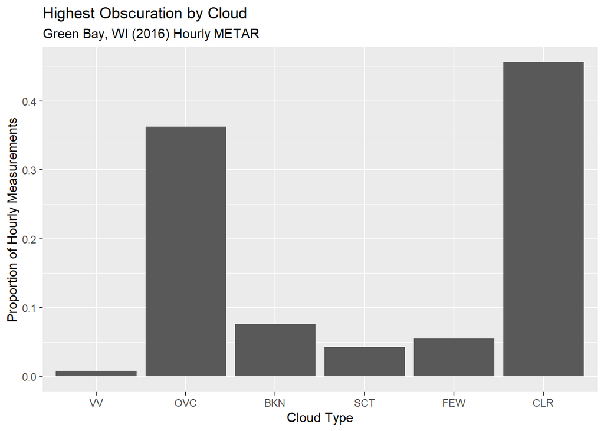

```
##
## *** Dimensions for the cloud matrix ***
## [1] 8803   12
```

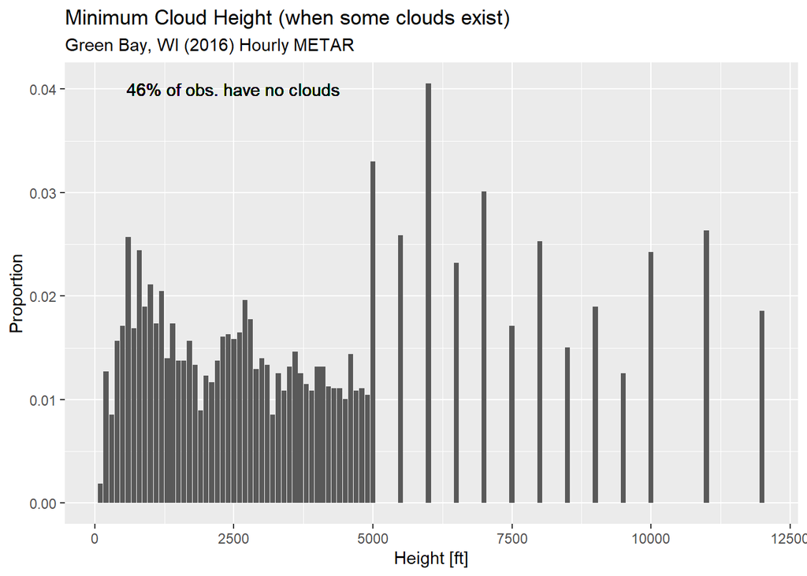

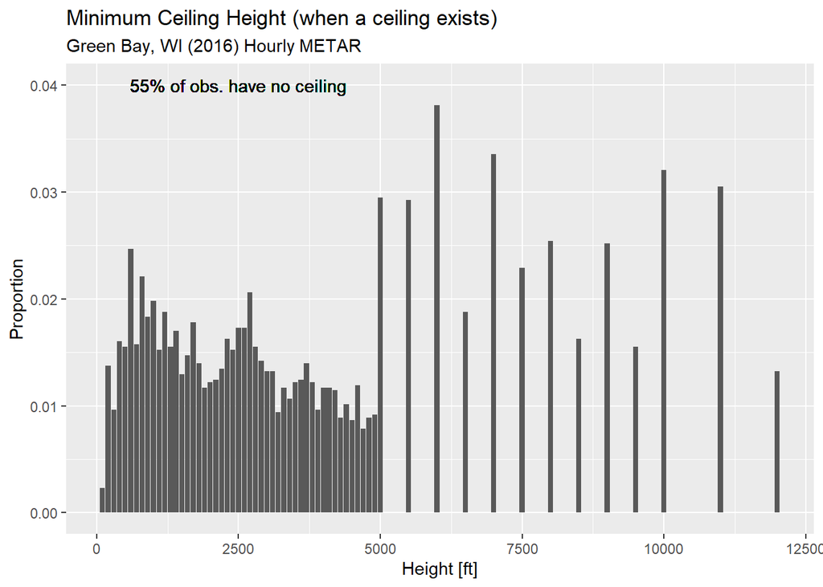

```r
cloudsGRB <- getClouds(fixGRB, cityName="Green Bay, WI (2016)")
```

The bindMETAR() function then puts everything together:

```r
# Function to bind the existing parsed METAR data with the cloud data
bindMETAR <- function(dfParse, tblClouds, lowCloud) {

    # Integrate the cloud data and convert month to a factor
    dfFull <- cbind(dfParse, tblClouds, lowCloud) %>%
        mutate(wType=factor(case_when(isCLR==1 ~ "CLR",
                                      isVV==1 ~ "VV",
                                      numOVC > 0 ~ "OVC",
                                      numBKN > 0 ~ "BKN",
                                      numSCT > 0 ~ "SCT",
                                      numFEW > 0 ~ "FEW",
                                      TRUE ~ "Error"
                                      ),
                            levels=c("VV", "OVC", "BKN", "SCT", "FEW", "CLR", "Error")
                            ),
               month=factor(lubridate::month(dtime), levels=1:12, labels=month.abb)
               )

    dfFull <- tibble::as_tibble(dfFull)
    glimpse(dfFull)

    dfFull
}
```

The function is run for the Green Bay data:

```r
fullGRB <- bindMETAR(fixGRB,
                     tblClouds=cloudsGRB$initClouds$tblClouds,
                     lowCloud=cloudsGRB$processedClouds$lowCloud
                     )
```

```
## Observations: 8,803
## Variables: 30
## $ METAR      <chr> "53Z 24004KT 10SM OVC024 M02/M06 A3014 RMK AO2 SLP217 T1...
## $ WindDir    <chr> "240", "280", "260", "250", "250", "260", "250", "250", ...
## $ WindSpeed  <int> 4, 5, 5, 6, 6, 7, 9, 9, 10, 9, 11, 11, 11, 11, 8, 12, 13...
## $ WindGust   <dbl> NA, NA, NA, NA, NA, NA, NA, NA, NA, NA, NA, NA, NA, NA, ...
## $ Dummy      <chr> " ", " ", " ", " ", " ", " ", " ", " ", " ", " ", " ", "...
## $ Visibility <dbl> 10, 10, 10, 10, 10, 10, 10, 10, 10, 10, 10, 10, 10, 10, ...
## $ TempC      <int> -2, -3, -3, -2, -3, -3, -3, -3, -3, -4, -4, -4, -4, -5, ...
## $ DewC       <int> -6, -6, -6, -6, -6, -6, -6, -6, -6, -6, -7, -7, -8, -9, ...
## $ Altimeter  <int> 3014, 3014, 3013, 3014, 3014, 3014, 3013, 3014, 3015, 30...
## $ SLP        <int> 217, 217, 215, 217, 217, 216, 215, 216, 222, 221, 221, 2...
## $ FahrC      <chr> "T10221056", "T10281056", "T10281056", "T10221061", "T10...
## $ dtime      <dttm> 2015-12-31 00:53:00, 2015-12-31 01:53:00, 2015-12-31 02...
## $ origMETAR  <chr> "KGRB 310053Z 24004KT 10SM OVC024 M02/M06 A3014 RMK AO2 ...
```

[output cut: 17 more lines]

A fully processed file for Green Bay, WI (2016) is now available for further analysis.

#### *Example #4: Cloud Processing Update*

The cloud extraction code above is verbose and mingles analysis with data wrangling. An improved approach is to focus on extracting and validating cloud data as a single function. Investigation of things like ceiling height and minimum cloud height can be left for the analysis stage.

Broadly speaking, there are seven types of clouds that can be reported in a METAR:

- SKC - skies are clear as determined by an automated sensor and confirmed by a human observer
- CLR - skies are clear as determined by an automated sensor (the sensor has a maximum height, and there may be clouds, including full overcast, above the maximum sensor height)
- VVddd - vertical visbility is obscured to ddd hundred feet, thus cloud levels are indeterminate
- OVCddd - there is an overcast at ddd hundred feet
- BKNddd - there is a broken (5/8 to 7/8) layer of clouds at ddd hundred feet
- SCTddd - there is a scattered (3/8 to 4/8) layer of clouds at ddd hundred feet
- FEWddd - there are a few (1/8 to 2/8) clouds at ddd hundred feet

Cloud layers are always graded according to the total obscuration up to and including that level. As such, it is impossible for FEW to be recorded at any level higher than the first recording of SCT/BKN/OVC/VV.

The cloud processing function is enahnced to perform the following:

- Determine whether SKC or CLR has been reported
- Extract up to 6 observations of (VV|OVC|BKN|SCT|FEW)\d{3}, and split their data in to cloud type and cloud height
- Confirm that every record has exactly 1 of SKC, CLR, or 1+ cloud type recorded (flag exceptions)
- Confirm that cloud types are strictly non-descending across FEW<SCT<BKN<OVC<VV
- Confirm that cloud heights are strictly ascending by observation
- Create wtype as the highest level of obscuration recorded in the cloud data

Example code includes:

```r
# Helper function to check if data are always ascending
# Subject to the rules that NA may follow anything but may only precede NA
ascVectorChecker <- function(y, strictly=TRUE) {

    # Checks a vector for being ascending (strictly so if strictly=TRUE)
    # Allows for NA provided that they never precede a numeric value

    if (all(is.na(y))) {
        # This is OK, if there are no numeric values then they are all NA
    } else if (all(is.na(y[2:length(y)]))) {
        # This is OK, single value is by definition ascending
    } else {
        # Confirm that NA are non-descending and that values are non-descending
        if (any(is.na(y) != cummax(is.na(y)))) {
            cat("\nIssue with NA preceding value -", y)
        } else {
            nonNA <- y[!is.na(y)]
            if (strictly) {
                if (min(diff(nonNA)) <= 0) {
                    cat("\nIssue with following values same or lower then preceding:", y, "\n")
                }
            } else {
                if (min(diff(nonNA)) < 0) {
                    cat("\nIssue with following values lower then preceding:", y, "\n")
                }
            }
        }
    }
}

# Helper function to verify non-descending cloud types, ascending cloud heights, return highest cloud type
validateClouds <- function(tbl,
                           cloudStates,
                           metVar="origMETAR",
                           nCols=6,
                           var1="cloud",
                           var2="cType",
                           var3="cLevel",
                           diagnoseVsError=5
                           ) {

    # STEP 1: Validate non-descending cloud types
    ascStates <- c(cloudStates, "")  # "" can be considered the highest cloud state; nothing should follow it
    cTypes <- tbl %>%
        select_at(vars(all_of(paste0(var2, 1:nCols)))) %>%
        mutate_all(~match(., ascStates))

    for (intCtr in 1:(nCols-1)) {
        descClouds <- as.vector(cTypes[, intCtr+1] - cTypes[, intCtr])
        mism <- sum(descClouds < 0)
        if (mism != 0) {
            cat("\nIssue with descending cloud types - ", mism, "records in column", intCtr+1, "\n")
            if (mism > diagnoseVsError) {
                stop("Too many issues, investigate and fix")
            } else {
                cat("Problematic METAR:\n")
                print(tbl[which(descClouds < 0), metVar])
            }
        }
    }


    # STEP 2: Validate ascending cloud types (NA is always fine, but cannot be followed by a number)
    cHeights <- tbl %>%
        select_at(vars(all_of(paste0(var3, 1:nCols))))

    apply(cHeights, 1, FUN=ascVectorChecker)


    # STEP 3: Extract the most obscured cloud type
    obscureTypes <- cTypes %>%
        mutate_all(~ifelse(. > length(cloudStates), 0, .)) %>%
        apply(1, FUN=max)

    obscureTypes <- ifelse(obscureTypes==0, length(cloudStates)+1, obscureTypes)
    ascStates[obscureTypes]

}


# Function to extract and wrangle cloud data contained in a METAR
extractAndWrangleClouds <- function(met,
                                    metVar,
                                    maxClouds=6,
                                    timeVar="dtime",
                                    soloStates=c("SKC", "CLR"),
                                    numStates=c("FEW", "SCT", "BKN", "OVC", "VV"),
                                    printDetails=FALSE,
                                    logFile="",
                                    useNAforIncomplete=FALSE
                                    ) {

    # Check that maxClouds <= 9
    if ((maxClouds != round(maxClouds, 0)) | (maxClouds < 1) | (maxClouds > 9)) {
        cat("\nThe maxClouds parameter must be an integer from 1-9, invalid entry of:", maxClouds)
        stop("Investigate and fix")
    }

    # Extract the metar record
    metAll <- met %>%
        pull(metVar)

    # If METAR is NA and if useNAForIncomplete=TRUE, make metAll=""
    if (useNAforIncomplete) {
        metAll[is.na(met$METAR)] <- ""
    }

    # Limit the METAR record to only clouds described prior to RMK
    metAll <- str_replace(metAll, pattern="RMK.*", replacement="")

    # Search for soloStates and bind them by column to the existing data
    for (soloState in soloStates) {
        ss <- str_extract_all(metAll, pattern=paste0(" ", soloState, " "), simplify=TRUE)
        if (dim(ss)[2] == 0) {
            resVec <- rep(0L, dim(ss)[1])
        } else {
            resVec <- apply(ss, 1, FUN=function(x) { sum(x!="") })
        }
        origNames <- names(met)
        met <- bind_cols(met, data.frame(resVec))
        names(met) <- c(origNames, paste0("n", soloState))
    }

    # Search and extract for numStates
    numPasted <- paste0("(", paste0(numStates, collapse="|"), ")")
    numRecords <- str_extract_all(metAll, pattern=paste0(numPasted, "\\d{3}"), simplify=TRUE)

    # Allow for up to maxClouds cloud types
    if (dim(numRecords)[2] > maxClouds) {
        cat("Too many clouds relative to passed paremeter maximum of", maxClouds, ": Dimensions -",
            dim(numRecords)
            )
        stop("Investigate and fix")
    }

    # Create columns for cType1-cType(maxClouds) and cLevel1-cLevel(maxClouds)
    for (intCtr in 1:maxClouds) {
        if (intCtr > dim(numRecords)[2]) {
            x <- rep("", dim(numRecords)[1])
        } else {
            x <- numRecords[, intCtr]
        }

        # Hard-coding that the heights are always three digits (as per the extraction)
        cType <- str_sub(x, 1, str_length(x)-3)
        cLevel <- str_sub(x, str_length(x)-2, -1)
        cLevel <- ifelse(cLevel=="", NA_integer_, 100*as.integer(cLevel))

        origNames <- names(met)
        met <- bind_cols(met, tibble::tibble(x, cType, cLevel))
        names(met) <- c(origNames, paste0(c("cloud", "cType", "cLevel"), intCtr))
    }

    # Validate clouds are sensible and return the most obscured state
    wType <- validateClouds(met, cloudStates=numStates, metVar=metVar, nCols=maxClouds)

    # Create a table of soloStates and wType
    tmp <- met %>%
        select_at(vars(all_of(paste0("n", soloStates)))) %>%
        mutate(obsc=wType)

    # Confirm that values in tmp are as expected
    # Should be either 0 or 1 total of soloStates counts
    # If 1 soloStates counts, should be wType=""
    # If 0 soloStates counts, should be wType!=""
    tmpSolos <- tmp %>%
        select_at(vars(all_of(paste0("n", soloStates)))) %>%
        apply(1, FUN=sum)

    tmpObsc <- ifelse(wType!="", 1, 0)
    tmpProbs <- (tmpSolos + tmpObsc != 1) & (!useNAforIncomplete | !is.na(met$METAR))

    if (sum(tmpProbs)==0) {
        # Write this to the main log file
        cat("\nwType as created from clouds data is consistent\n")
    } else {
        # Write this to the main log file
        xText <- ifelse(logFile=="", ":", "(see logfile):")
        cat("\nThere are", sum(tmpProbs), "issues with clouds data", xText, "\n\n")
        cat("\nIssues with clouds data:\n", file=logFile, append=TRUE)
        met %>%
            select_at(vars(all_of(c(timeVar, metVar)))) %>%
            filter(tmpProbs) %>%
            write.table(file=logFile, append=TRUE, row.names=FALSE, col.names=FALSE)
        cat("\n", file=logFile, append=TRUE)
    }

    # Print the summaries by key type
    if (printDetails) {
        tmp %>%
            group_by_all() %>%
            summarize(n=n()) %>%
            print()
    }

    # Create the final wType variable, attach to the met data, and convert to a factor
    # Take the wType variable and overwrite in the soloStates if they exist
    for (soloVar in rev(soloStates)) {
        soloVec <- tmp %>%
            pull(paste0("n", soloVar))
        wType <- ifelse(soloVec > 0, soloVar, wType)
    }
    wType <- ifelse(wType=="", "Error", wType)

    met <- met %>%
        mutate(wType=factor(wType, levels=c(rev(numStates), rev(soloStates), "Error")))

    # Show count by wType
    met %>%
        count(wType) %>%
        print()

    # Return the database
    met

}
```

And the routine can then be run to create fullGRB2:

```r
fullGRB2 <- extractAndWrangleClouds(fixGRB, metVar="origMETAR")
```

```
##
## There are 3 issues with clouds data :
##
##
## Issues with clouds data:
## 2016-09-14 17:53:00 "KGRB 141753Z VRB03KT A3031 RMK AO2 SLPNO 10194 20133 52003 RVRNO $"
## 2016-12-19 12:53:00 "KGRB 191253Z 22007KT 10SM M22/M26 A3050 RMK AO2 SLP352 T12171256"
## 2016-12-21 12:53:00 "KGRB 211253Z 20005KT 10SM M04/M07 A3006 RMK AO2 SLP189 T10391067"
##
## # A tibble: 7 x 2
##   wType     n
##   <fct> <int>
## 1 VV       73
## 2 OVC    3191
## 3 BKN     668
## 4 SCT     373
## 5 FEW     483
## 6 CLR    4012
## 7 Error     3
```

```r
# Variables in fullGRB but not in fullGRB2
setdiff(names(fullGRB), names(fullGRB2))
```

```
##  [1] "isCLR"  "isVV"   "htVV"   "numFEW" "numSCT" "numBKN" "numOVC" "lowVV"
##  [9] "lowOVC" "lowBKN" "lowSCT" "lowFEW" "month"
```

```r
# Variables in fullGRB2 but not in fullGRB
setdiff(names(fullGRB2), names(fullGRB))
```

```
##  [1] "nSKC"    "nCLR"    "cloud1"  "cType1"  "cLevel1" "cloud2"  "cType2"
##  [8] "cLevel2" "cloud3"  "cType3"  "cLevel3" "cloud4"  "cType4"  "cLevel4"
## [15] "cloud5"  "cType5"  "cLevel5" "cloud6"  "cType6"  "cLevel6"
```

```r
# Variables in both fullGRB2 and fullGRB
namesBoth <- intersect(names(fullGRB2), names(fullGRB))
namesBoth
```

```
##  [1] "METAR"      "WindDir"    "WindSpeed"  "WindGust"   "Dummy"
##  [6] "Visibility" "TempC"      "DewC"       "Altimeter"  "SLP"
## [11] "FahrC"      "dtime"      "origMETAR"  "TempF"      "DewF"
## [16] "modSLP"     "wType"
```

```r
# Convert fullGRB to have same levels as fullGRB2
testGRB <- fullGRB %>%
    mutate(wType=factor(wType, levels=levels(fullGRB2$wType)))

cat("\n")
```

```r
# Comparisons for equality for variables in both
for (colName in namesBoth) {
    ae <- all.equal(testGRB[, colName], fullGRB2[, colName])
    if (isTRUE(ae)) {
        cat("100% Match for Variable:", colName, "\n")
    } else {
        cat("Mismatch for variable:", colName, "-", ae, "\n")
    }
}
```

```
## 100% Match for Variable: METAR
## 100% Match for Variable: WindDir
## 100% Match for Variable: WindSpeed
## 100% Match for Variable: WindGust
## 100% Match for Variable: Dummy
## 100% Match for Variable: Visibility
## 100% Match for Variable: TempC
## 100% Match for Variable: DewC
## 100% Match for Variable: Altimeter
## 100% Match for Variable: SLP
## 100% Match for Variable: FahrC
## 100% Match for Variable: dtime
## 100% Match for Variable: origMETAR
## 100% Match for Variable: TempF
## 100% Match for Variable: DewF
## 100% Match for Variable: modSLP
## 100% Match for Variable: wType
```

The routine seems to be working well and is extracting a greater portion of cloud data which may be useful for later analysis:

- Every cloud record
- Every cloud type
- Every cloud height

Further, checks have been automated to be sure that cloud types are non-descending and cloud heights are strictly ascending (with the exception that NA can follow anything but can only precede NA).

The wType variable is created as a factor and reflects that SKC/CLR are acceptable states. Further the functions check to ensure that there is exactly 1 of SKC, CLR, or wType!="".

Month is also a valuable variable for analysis, though it is contained in ‘dtime’ already. Further checks should be run to confirm that ‘dtime’ is aligned to origMETAR.

#### *Example #5: Checking Time Properties*

At various times, the ‘dtime’ variable is used to classify information that is pulled from ‘origMETAR’. It will be useful to confirm that the variables are well aligned as follows:

- The origMETAR will have ddddddZ where the first dd are the two-digit day, the second dd are the two-digit hour, the third dd are the two-digit minutes, and the Z reflects UTC/Zulu time
- The corresponding data from dtime should match, and year, month, and day can also be extracted during this process

Example code includes:

```r
# Function to check alignment of Zulu time in a METAR with an associated date-time variable
checkTimeProperties <- function(met,
                                metVar,
                                timeVar
                                ) {

    # Extract the Zulu days and times from metVar
    zTime <- met %>%
        pull(metVar) %>%
        str_extract(pattern="\\d{6}Z")

    # Extract the day, hour, and minute from timeVar
    dTime <- met %>%
        pull(timeVar)

    # Create the expected Zulu string from dTime
    expTime <- paste0(str_pad(lubridate::day(dTime), width=2, pad="0"),
                      str_pad(lubridate::hour(dTime), width=2, pad="0"),
                      str_pad(lubridate::minute(dTime), width=2, pad="0"),
                      "Z"
                      )

    # Check for consistency
    mism <- (zTime != expTime)
    if (sum(mism) == 0) {
        cat("\nAll Zulu times in the METAR are consistent with the datetime variable\n")
    } else {
        cat("\nThere are",
            sum(mism),
            "inconsistencies between Zulu times in the METAR and the datetime variable\n",
            "First 10 examples include:\n"
            )
        data.frame(zTime, dTime, expTime, mism) %>%
            filter(mism) %>%
            head(10)
    }

    # Create key variables and return them
    met <- met %>%
        mutate(year=lubridate::year(dTime),
               monthint=lubridate::month(dTime),
               month=factor(monthint, levels=1:12, labels=month.abb[1:12]),
               day=lubridate::day(dTime)
               )

    met

}

fullGRB3 <- checkTimeProperties(fullGRB2, metVar="origMETAR", timeVar="dtime")
```

```
##
## All Zulu times in the METAR are consistent with the datetime variable
```

```r
# Variables in fullGRB but not in fullGRB3
setdiff(names(fullGRB), names(fullGRB3))
```

```
##  [1] "isCLR"  "isVV"   "htVV"   "numFEW" "numSCT" "numBKN" "numOVC" "lowVV"
##  [9] "lowOVC" "lowBKN" "lowSCT" "lowFEW"
```

```r
# Variables in fullGRB3 but not in fullGRB
setdiff(names(fullGRB3), names(fullGRB))
```

```
##  [1] "nSKC"     "nCLR"     "cloud1"   "cType1"   "cLevel1"  "cloud2"
##  [7] "cType2"   "cLevel2"  "cloud3"   "cType3"   "cLevel3"  "cloud4"
## [13] "cType4"   "cLevel4"  "cloud5"   "cType5"   "cLevel5"  "cloud6"
## [19] "cType6"   "cLevel6"  "year"     "monthint" "day"
```

```r
# Variables in both fullGRB3 and fullGRB
namesBoth <- intersect(names(fullGRB3), names(fullGRB))
namesBoth
```

```
##  [1] "METAR"      "WindDir"    "WindSpeed"  "WindGust"   "Dummy"
##  [6] "Visibility" "TempC"      "DewC"       "Altimeter"  "SLP"
## [11] "FahrC"      "dtime"      "origMETAR"  "TempF"      "DewF"
## [16] "modSLP"     "wType"      "month"
```

```r
# Convert fullGRB to have same levels as fullGRB3
testGRB <- fullGRB %>%
    mutate(wType=factor(wType, levels=levels(fullGRB3$wType)))

cat("\n")
```

```r
# Comparisons for equality for variables in both
for (colName in namesBoth) {
    ae <- all.equal(testGRB[, colName], fullGRB3[, colName])
    if (isTRUE(ae)) {
        cat("100% Match for Variable:", colName, "\n")
    } else {
        cat("Mismatch for variable:", colName, "-", ae, "\n")
    }
}
```

```
## 100% Match for Variable: METAR
## 100% Match for Variable: WindDir
## 100% Match for Variable: WindSpeed
## 100% Match for Variable: WindGust
## 100% Match for Variable: Dummy
## 100% Match for Variable: Visibility
## 100% Match for Variable: TempC
## 100% Match for Variable: DewC
## 100% Match for Variable: Altimeter
## 100% Match for Variable: SLP
## 100% Match for Variable: FahrC
## 100% Match for Variable: dtime
## 100% Match for Variable: origMETAR
## 100% Match for Variable: TempF
## 100% Match for Variable: DewF
## 100% Match for Variable: modSLP
## 100% Match for Variable: wType
## 100% Match for Variable: month
```

The times are aligned, allowing for confident use of the ‘dtime’ variable in analysis. Further, the year, month (as both integer and factor), and day have been extracted for easy availability in future analysis.

Next steps are to integrate the full download and processing, and to save a final file to the local drive so that processing need only be run once.

#### *Example #6: Integrate Processing Steps*

The processing steps can be integrated, and the results can be saved as a file for use later.

Key steps include:

- findHourlyReportingTimes() - get the hourly reporting time for use in the target METAR string
- readMETAR() - extract only hourly observations, check for expected times and record uniqueness
- initialParseMETAR() - parse the raw METAR data based on an expected regex pattern
- convertMETAR() - converts characters from the parsed METAR file to meaningful numbers for analysis
- fixMETAR() - corrects for issues with extracting and converting visibility, wind gusts, and SLP
- extractAndWrangleClouds() - extract cloud data from the METAR; determine cloud types, minimum heights, and minimum ceilings; and bind the cloud results to the METAR frame
- checkTimePropoerties() - confirm that times are aligned between ‘dtime’ and ‘origMETAR’ and add year, month (as integer and as factored mmm abbreviation), and day

Example code includes:

```r
integrateProcessingMETAR <- function(locRawMETAR,
                                     startDay,
                                     endDay,
                                     genMET,
                                     labsMET,
                                     saveLoc=NULL,
                                     ovrWrite=FALSE,
                                     ovrWriteError=FALSE,
                                     colTypes=NULL,
                                     threshError=0.75
                                     ) {

    # Convert startDay and endDay to date
    startDay=as.Date(startDay)
    endDay=as.Date(endDay)

    # Find the hourly reporting times, and validate that they have 'enough' data at the peak hour
    keyZulu <- findHourlyReportingTimes(metFile=locRawMETAR, threshError=threshError)

    # Use the Zulu time to create the expected minimum time and number of days
    zuluNumber <- as.numeric(str_sub(keyZulu, 1, -2))
    dtString <- paste0(as.character(startDay),
                       " 00:",
                       str_pad(as.character(zuluNumber), width=2, pad="0"),
                       ":00"
                       )

    # Read in the raw METAR file
    readFile <- readMETAR(locRawMETAR,
                          timeZ=keyZulu,
                          expMin=as.POSIXct(dtString, tz="UTC"),
                          expDays=1 + as.integer(endDay - startDay),
                          colTypes=colTypes
                          )

    # Create the valMet string by pasting the key Zulu time to the front of it
    valMet <- paste0(keyZulu, genMET)

    # Make the initial pass at parsing the raw METAR file
    initFile <- initialParseMETAR(readFile, val=valMet, labs=labsMET, glimpseFinal=TRUE)

    # Convert the initially parsed METAR file
    # This process is quite hard-coded to a specific format (which is fine for now)
    convFile <- convertMETAR(initFile)

    # Fix the converted METAR file - visibility, wind gusts, SLP
    # This process is quite hard-coded to a specific format (which is fine for now)
    fixFile <- fixMETAR(convFile)

    # Extract and wrangle the clouds from the METAR
    # This process is quite hard-coded to a specific format (which is fine for now)
    fullFile <- extractAndWrangleClouds(fixFile, metVar="origMETAR")

    # Check the time properties and add year, month (as integer and factor), day as variables
    finalFile <- checkTimeProperties(fullFile, metVar="origMETAR", timeVar="dtime")

    # If saveLoc is provided, save the file using RDS to the provided location; return it otherwise
    if (!is.null(saveLoc)) {
        if (file.exists(saveLoc)) {
            if (ovrWrite) {
                cat("\nOver-writing existing file:", saveLoc, "\n\n")
                saveRDS(finalFile, file=saveLoc)
            } else {
                cat("\nFile already exists and NOT over-written:", saveLoc, "\n\n")
                if (ovrWriteError) {
                    stop("Aborting due to ovrWriteError=TRUE\n\n")
                }
            }
        } else {
            cat("\nCreating file:", saveLoc, "\n\n")
            saveRDS(finalFile, file=saveLoc)
        }
    } else {
        return(finalFile)
    }

}
```

The process can then be run on the Green Bay data to verify consistency of results:

```r
# The generally expected METAR parsing string
genMET <- ".*?(VRB|\\d{3})(\\d{2})(G\\d{2})?KT(.*?)(\\d{1,2}SM).*?\\s(M?\\d{2})/(M?\\d{2}).*?(A\\d{4}).*?RMK.*?(SLP\\d{3}).*?(T\\d{8})"

# The generally expected METAR parsing column labels
labsMet <- c("METAR", "WindDir", "WindSpeed", "WindGust", "Dummy", "Visibility",
             "TempC", "DewC", "Altimeter", "SLP", "FahrC"
             )

# Test the process on the Green Bay data
testGRB <- integrateProcessingMETAR("./RInputFiles/metar_kgrb_2016.txt",
                         startDay="2015-12-31",
                         endDay="2017-01-01",
                         colTypes=metType,
                         genMET=genMET,
                         labsMET=labsMet
                         )
```

```
##
## Most common 10 times for file: ./RInputFiles/metar_kgrb_2016.txt
## .
##  53Z  02Z  33Z  00Z  03Z  17Z  18Z  27Z  16Z  51Z
## 8803   64   64   63   62   58   57   57   55   55
##
## The most common Zulu time for ./RInputFiles/metar_kgrb_2016.txt is 53Z
## Frequency is 77.8 % ( 8803 of 11309 )
##
## *** OBSERVATIONS EXPECTED BUT NOT RECORDED ***
##  [1] "2016-01-06 04:53:00 UTC" "2016-01-19 19:53:00 UTC"
##  [3] "2016-01-26 07:53:00 UTC" "2016-03-09 09:53:00 UTC"
##  [5] "2016-05-06 11:53:00 UTC" "2016-05-06 12:53:00 UTC"
##  [7] "2016-05-11 08:53:00 UTC" "2016-05-28 04:53:00 UTC"
##  [9] "2016-06-17 23:53:00 UTC" "2016-06-18 00:53:00 UTC"
```

[output cut: 102 more lines]

```
##
##  *** Number of NA values ***
##      METAR    WindDir  WindSpeed   WindGust      Dummy Visibility      TempC
##         62         62         62       8803         62         62         62
##       DewC  Altimeter        SLP      FahrC      dtime  origMETAR      TempF
##         62         62         62         62          0          0         62
##       DewF
##         62
##
## Visibilities after correcting for fractions:
## 0.25  0.5 0.75    1 1.25  1.5 1.75    2  2.5    3    4    5    6    7    8    9
##   41   46   28   31   35   28   24   54   66  109  143  165  158  162  169  261
##   10 <NA>
## 7223   60
##
##
## Counts of wind gusts extracted:
##   14   15   16   17   18   19   20   21   22   23   24   25   26   27   28   29
##    4   22   30   48   59   84   88   78   93   75   61   51   36   29   30    5
##   30   31   32   33   34   35   36   37   38   40   41   43   44   46 <NA>
##   21   10    3    4    3    2    2    2    4    3    1    1    1    1 7952
```

```
##
## Issues with clouds data at records:
## # A tibble: 3 x 2
##   dtime               origMETAR
##   <dttm>              <chr>
## 1 2016-09-14 17:53:00 KGRB 141753Z VRB03KT A3031 RMK AO2 SLPNO 10194 20133 5200~
## 2 2016-12-19 12:53:00 KGRB 191253Z 22007KT 10SM M22/M26 A3050 RMK AO2 SLP352 T1~
## 3 2016-12-21 12:53:00 KGRB 211253Z 20005KT 10SM M04/M07 A3006 RMK AO2 SLP189 T1~
## # A tibble: 7 x 2
##   wType     n
##   <fct> <int>
## 1 VV       73
## 2 OVC    3191
## 3 BKN     668
## 4 SCT     373
## 5 FEW     483
## 6 CLR    4012
## 7 Error     3
##
## All Zulu times in the METAR are consistent with the datetime variable
```

```r
# Test for equality across the files
identical(testGRB, fullGRB3)
```

```
## [1] TRUE
```

```r
# Test the process on the Green Bay data, including saving as RDS (allow for over-writing)
integrateProcessingMETAR("./RInputFiles/metar_kgrb_2016.txt",
                         startDay="2015-12-31",
                         endDay="2017-01-01",
                         colTypes=metType,
                         genMET=genMET,
                         labsMET=labsMet,
                         saveLoc="./RInputFiles/ProcessedMETAR/_TESTONLY_metar_kgrb_2016,rds",
                         ovrWrite=TRUE
                         )
```

```
##
## Most common 10 times for file: ./RInputFiles/metar_kgrb_2016.txt
## .
##  53Z  02Z  33Z  00Z  03Z  17Z  18Z  27Z  16Z  51Z
## 8803   64   64   63   62   58   57   57   55   55
##
## The most common Zulu time for ./RInputFiles/metar_kgrb_2016.txt is 53Z
## Frequency is 77.8 % ( 8803 of 11309 )
##
## *** OBSERVATIONS EXPECTED BUT NOT RECORDED ***
##  [1] "2016-01-06 04:53:00 UTC" "2016-01-19 19:53:00 UTC"
##  [3] "2016-01-26 07:53:00 UTC" "2016-03-09 09:53:00 UTC"
##  [5] "2016-05-06 11:53:00 UTC" "2016-05-06 12:53:00 UTC"
##  [7] "2016-05-11 08:53:00 UTC" "2016-05-28 04:53:00 UTC"
##  [9] "2016-06-17 23:53:00 UTC" "2016-06-18 00:53:00 UTC"
```

[output cut: 102 more lines]

```
##
##  *** Number of NA values ***
##      METAR    WindDir  WindSpeed   WindGust      Dummy Visibility      TempC
##         62         62         62       8803         62         62         62
##       DewC  Altimeter        SLP      FahrC      dtime  origMETAR      TempF
##         62         62         62         62          0          0         62
##       DewF
##         62
##
## Visibilities after correcting for fractions:
## 0.25  0.5 0.75    1 1.25  1.5 1.75    2  2.5    3    4    5    6    7    8    9
##   41   46   28   31   35   28   24   54   66  109  143  165  158  162  169  261
##   10 <NA>
## 7223   60
##
##
## Counts of wind gusts extracted:
##   14   15   16   17   18   19   20   21   22   23   24   25   26   27   28   29
##    4   22   30   48   59   84   88   78   93   75   61   51   36   29   30    5
##   30   31   32   33   34   35   36   37   38   40   41   43   44   46 <NA>
##   21   10    3    4    3    2    2    2    4    3    1    1    1    1 7952
```

```
##
## Issues with clouds data at records:
## # A tibble: 3 x 2
##   dtime               origMETAR
##   <dttm>              <chr>
## 1 2016-09-14 17:53:00 KGRB 141753Z VRB03KT A3031 RMK AO2 SLPNO 10194 20133 5200~
## 2 2016-12-19 12:53:00 KGRB 191253Z 22007KT 10SM M22/M26 A3050 RMK AO2 SLP352 T1~
## 3 2016-12-21 12:53:00 KGRB 211253Z 20005KT 10SM M04/M07 A3006 RMK AO2 SLP189 T1~
## # A tibble: 7 x 2
##   wType     n
##   <fct> <int>
## 1 VV       73
## 2 OVC    3191
## 3 BKN     668
## 4 SCT     373
## 5 FEW     483
## 6 CLR    4012
## 7 Error     3
##
## All Zulu times in the METAR are consistent with the datetime variable
##
## Over-writing existing file: ./RInputFiles/ProcessedMETAR/_TESTONLY_metar_kgrb_2016,rds
```

```r
# Test for equality across the files when read in
identical(readRDS("./RInputFiles/ProcessedMETAR/_TESTONLY_metar_kgrb_2016,rds"), fullGRB3)
```

```
## [1] TRUE
```

The processed Green Bay data matches what was produced by running all functions sequentially.

The process can then be run for all of the processed METAR files:

```r
# Run for each of the 6 airports and save the processed file
for (airport in c("kmke", "kmsn", "kgrb", "ktvc", "kgrr", "kind")) {

    year <- 2016
    coreString <- paste0("metar_", airport, "_", as.character(year))

    cat("\nProcessing Airport:", airport)
    integrateProcessingMETAR(paste0("./RInputFiles/", coreString, ".txt"),
                             startDay=paste0(as.character(year-1), "-12-31"),
                             endDay=paste0(as.character(year+1), "-01-01"),
                             colTypes=metType,
                             genMET=genMET,
                             labsMET=labsMet,
                             saveLoc=paste0("./RInputFiles/ProcessedMETAR/", coreString, ".rds"),
                             ovrWrite=TRUE
                             )
    cat("\nFinished Processing Airport:", airport, "\n")

}
```

```
##
## Processing Airport: kmke
## Most common 10 times for file: ./RInputFiles/metar_kmke_2016.txt
## .
##  52Z  59Z  33Z  16Z  29Z  09Z  48Z  39Z  44Z  14Z
## 8808   55   54   50   47   46   44   43   43   42
##
## The most common Zulu time for ./RInputFiles/metar_kmke_2016.txt is 52Z
## Frequency is 83.3 % ( 8808 of 10573 )
##
## *** OBSERVATIONS EXPECTED BUT NOT RECORDED ***
##  [1] "2016-01-09 06:52:00 UTC" "2016-01-26 00:52:00 UTC"
##  [3] "2016-02-08 15:52:00 UTC" "2016-03-10 22:52:00 UTC"
##  [5] "2016-06-08 00:52:00 UTC" "2016-06-08 10:52:00 UTC"
##  [7] "2016-06-11 20:52:00 UTC" "2016-06-17 23:52:00 UTC"
##  [9] "2016-06-18 00:52:00 UTC" "2016-07-01 03:52:00 UTC"
## [11] "2016-07-06 10:52:00 UTC" "2016-07-13 14:52:00 UTC"
## [13] "2016-07-13 15:52:00 UTC" "2016-07-13 16:52:00 UTC"
## [15] "2016-07-13 17:52:00 UTC" "2016-08-05 07:52:00 UTC"
## [17] "2016-08-10 17:52:00 UTC" "2016-08-10 18:52:00 UTC"
## [19] "2016-08-25 04:52:00 UTC" "2016-10-26 08:52:00 UTC"
## [21] "2016-10-26 09:52:00 UTC" "2016-11-21 00:52:00 UTC"
## [23] "2016-12-03 08:52:00 UTC" "2016-12-27 15:52:00 UTC"
##
## *** OBSERVATIONS RECORDED BUT NOT EXPECTED ***
## POSIXct of length 0
##
## *** Are the extracted records unique? ***
##  TRUE
##
## *** Tentative Summary of Element Parsing ***
## .
## FALSE  TRUE
##    15  8793
##
## *** Data Not Matched ***
##  [1] "KMKE 242252Z 10SM BKN075 BKN090 25/15 A2991 RMK AO2 SLP125 T02500150 $"
##  [2] "KMKE 071952Z 32008KT 10SM FEW029 BKN037 17/08 A2987"
##  [3] "KMKE 072352Z 10007KT 10SM FEW037 BKN050 16/10 A2987 RMK T01620099"
##  [4] "KMKE 080152Z 13005KT 10SM BKN055 14/11 A2988 RMK T01390106"
```

[output cut: 13 more lines]

```
## Observations: 8,808
## Variables: 13
## $ METAR      <chr> "52Z 27007KT 10SM OVC022 M01/M06 A3018 RMK AO2 SLP230 T1...
## $ WindDir    <chr> "270", "250", "240", "250", "240", "260", "240", "230", ...
## $ WindSpeed  <chr> "07", "05", "05", "06", "04", "04", "06", "08", "07", "0...
## $ WindGust   <chr> NA, NA, NA, NA, NA, NA, NA, NA, NA, NA, NA, NA, NA, NA, ...
## $ Dummy      <chr> " ", " ", " ", " ", " ", " ", " ", " ", " ", " ", " ", "...
## $ Visibility <chr> "10SM", "10SM", "10SM", "10SM", "10SM", "10SM", "10SM", ...
## $ TempC      <chr> "M01", "M01", "M02", "M02", "M02", "M02", "M02", "M02", ...
## $ DewC       <chr> "M06", "M06", "M06", "M06", "M06", "M06", "M06", "M07", ...
## $ Altimeter  <chr> "A3018", "A3018", "A3018", "A3017", "A3019", "A3017", "A...
## $ SLP        <chr> "SLP230", "SLP231", "SLP230", "SLP228", "SLP232", "SLP22...
## $ FahrC      <chr> "T10111061", "T10111061", "T10171056", "T10171056", "T10...
## $ dtime      <dttm> 2015-12-31 00:52:00, 2015-12-31 01:52:00, 2015-12-31 02...
## $ origMETAR  <chr> "KMKE 310052Z 27007KT 10SM OVC022 M01/M06 A3018 RMK AO2 ...
```

```
##
##  *** Number of NA values ***
##      METAR    WindDir  WindSpeed   WindGust      Dummy Visibility      TempC
##         15         15         15       8808         15         15         15
##       DewC  Altimeter        SLP      FahrC      dtime  origMETAR      TempF
##         15         15         15         15          0          0         15
##       DewF
##         15
##
## Visibilities after correcting for fractions:
## 0.125  0.25   0.5  0.75     1  1.25   1.5  1.75     2   2.5     3     4     5
##     7    51    51    22    48    29    46    22    61    41   112    87   125
##     6     7     8     9    10  <NA>
##   139   189   230   322  7211    15
##
##
## Counts of wind gusts extracted:
##   14   15   16   17   18   19   20   21   22   23   24   25   26   27   28   29
##    4   11   24   61  114  127  156  162  130  140  113  107   74   63   50   30
##   30   31   32   33   34   35   36   37   38   39   40   41   42   43   44   49
##   23   15    9    8    7    4    1    4    4    6    1    1    1    2    1    1
##   51 <NA>
##    1 7353
```

```
##
## wType as created from clouds data is consistent# A tibble: 6 x 2
##   wType     n
##   <fct> <int>
## 1 VV       68
## 2 OVC    2678
## 3 BKN    2417
## 4 SCT    1113
## 5 FEW    1599
## 6 CLR     933
##
## All Zulu times in the METAR are consistent with the datetime variable
##
## Over-writing existing file: ./RInputFiles/ProcessedMETAR/metar_kmke_2016.rds
##
```

[output cut: 209 more lines]

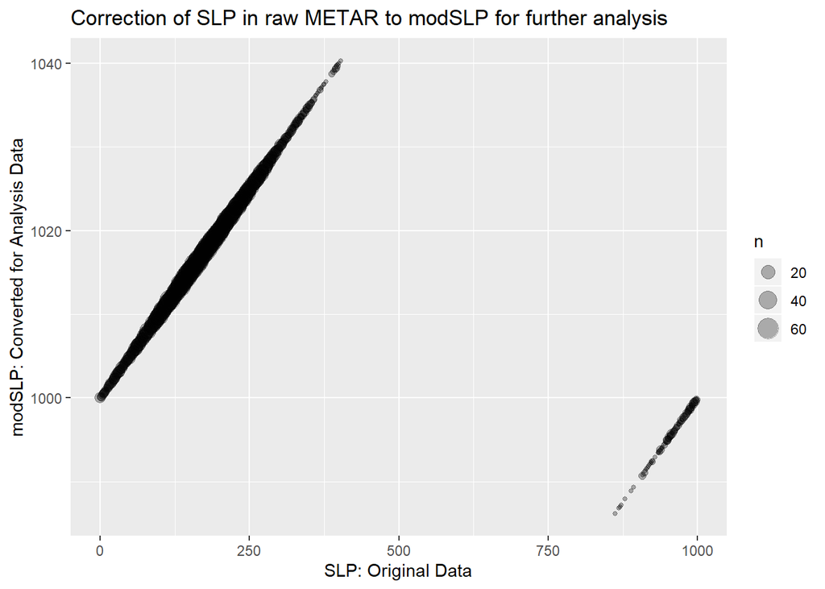

```
##
##  *** Number of NA values ***
##      METAR    WindDir  WindSpeed   WindGust      Dummy Visibility      TempC
##        149        149        149       8798        149        149        149
##       DewC  Altimeter        SLP      FahrC      dtime  origMETAR      TempF
##        149        149        149        149          0          0        149
##       DewF
##        149
##
## Visibilities after correcting for fractions:
##     0 0.125  0.25   0.5  0.75     1  1.25   1.5  1.75     2   2.5     3     4
##     2     6    32    29    29    65    13    39    19    82    61    93   121
##     5     6     7     8     9    10    16  <NA>
##   162   148   164   179   289  7115     2   148
##
##
## Counts of wind gusts extracted:
##   13   14   15   16   17   18   19   20   21   22   23   24   25   26   27   28
##    1   32   95  135  118  148  113   93   89   65   58   36   35   32   23   18
##   29   30   31   32   33   34   35   37   42   43 <NA>
##    6    5    2    6    5    1    1    1    1    1 7678
```

```
##
## Issue with following values same or lower then preceding: 3800 2500 NA NA NA NA
##
## wType as created from clouds data is consistent# A tibble: 6 x 2
##   wType     n
##   <fct> <int>
## 1 VV       63
## 2 OVC    3069
## 3 BKN    2185
## 4 SCT     716
## 5 FEW    1046
## 6 CLR    1719
##
## All Zulu times in the METAR are consistent with the datetime variable
##
```

[output cut: 122 more lines]

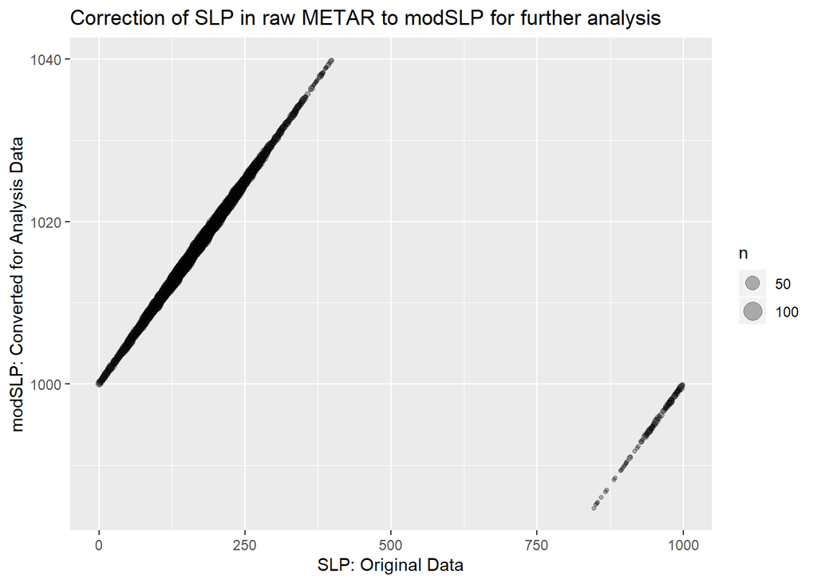

```
##
##  *** Number of NA values ***
##      METAR    WindDir  WindSpeed   WindGust      Dummy Visibility      TempC
##         62         62         62       8803         62         62         62
##       DewC  Altimeter        SLP      FahrC      dtime  origMETAR      TempF
##         62         62         62         62          0          0         62
##       DewF
##         62
##
## Visibilities after correcting for fractions:
## 0.25  0.5 0.75    1 1.25  1.5 1.75    2  2.5    3    4    5    6    7    8    9
##   41   46   28   31   35   28   24   54   66  109  143  165  158  162  169  261
##   10 <NA>
## 7223   60
##
##
## Counts of wind gusts extracted:
##   14   15   16   17   18   19   20   21   22   23   24   25   26   27   28   29
##    4   22   30   48   59   84   88   78   93   75   61   51   36   29   30    5
##   30   31   32   33   34   35   36   37   38   40   41   43   44   46 <NA>
##   21   10    3    4    3    2    2    2    4    3    1    1    1    1 7952
```

```
##
## Issues with clouds data at records:
## # A tibble: 3 x 2
##   dtime               origMETAR
##   <dttm>              <chr>
## 1 2016-09-14 17:53:00 KGRB 141753Z VRB03KT A3031 RMK AO2 SLPNO 10194 20133 5200~
## 2 2016-12-19 12:53:00 KGRB 191253Z 22007KT 10SM M22/M26 A3050 RMK AO2 SLP352 T1~
## 3 2016-12-21 12:53:00 KGRB 211253Z 20005KT 10SM M04/M07 A3006 RMK AO2 SLP189 T1~
## # A tibble: 7 x 2
##   wType     n
##   <fct> <int>
## 1 VV       73
## 2 OVC    3191
## 3 BKN     668
## 4 SCT     373
## 5 FEW     483
## 6 CLR    4012
## 7 Error     3
##
## All Zulu times in the METAR are consistent with the datetime variable
##
## Over-writing existing file: ./RInputFiles/ProcessedMETAR/metar_kgrb_2016.rds
##
##
## Finished Processing Airport: kgrb
##
## Processing Airport: ktvc
## Most common 10 times for file: ./RInputFiles/metar_ktvc_2016.txt
## .
##  53Z  07Z  39Z  49Z  46Z  23Z  17Z  32Z  08Z  35Z
## 8814   63   62   62   60   58   56   54   53   53
##
## The most common Zulu time for ./RInputFiles/metar_ktvc_2016.txt is 53Z
## Frequency is 78.7 % ( 8814 of 11196 )
##
## *** OBSERVATIONS EXPECTED BUT NOT RECORDED ***
##  [1] "2016-01-11 09:53:00 UTC" "2016-01-18 02:53:00 UTC"
##  [3] "2016-01-21 17:53:00 UTC" "2016-03-16 11:53:00 UTC"
##  [5] "2016-05-06 11:53:00 UTC" "2016-05-06 12:53:00 UTC"
##  [7] "2016-06-17 23:53:00 UTC" "2016-06-18 00:53:00 UTC"
```

[output cut: 39 more lines]

```
## Observations: 8,814
## Variables: 13
## $ METAR      <chr> "53Z 25006KT 10SM BKN025 BKN030 OVC065 M01/M05 A3009 RMK...
## $ WindDir    <chr> "250", "240", "260", "240", "240", "250", "230", "220", ...
## $ WindSpeed  <chr> "06", "05", "06", "05", "04", "05", "03", "04", "04", "0...
## $ WindGust   <chr> NA, NA, NA, NA, NA, NA, NA, NA, NA, NA, NA, NA, NA, NA, ...
## $ Dummy      <chr> " ", " ", " ", " ", " ", " ", " ", " ", " ", " ", " ", "...
## $ Visibility <chr> "10SM", "10SM", "10SM", "10SM", "10SM", "10SM", "10SM", ...
## $ TempC      <chr> "M01", "M01", "M01", "M01", "M01", "M01", "M01", "M01", ...
## $ DewC       <chr> "M05", "M05", "M05", "M05", "M05", "M06", "M05", "M05", ...
## $ Altimeter  <chr> "A3009", "A3009", "A3009", "A3009", "A3009", "A3009", "A...
## $ SLP        <chr> "SLP198", "SLP199", "SLP196", "SLP197", "SLP199", "SLP19...
## $ FahrC      <chr> "T10061050", "T10061050", "T10061050", "T10111050", "T10...
## $ dtime      <dttm> 2015-12-31 00:53:00, 2015-12-31 01:53:00, 2015-12-31 02...
## $ origMETAR  <chr> "KTVC 310053Z 25006KT 10SM BKN025 BKN030 OVC065 M01/M05 ...
```

```
##
##  *** Number of NA values ***
##      METAR    WindDir  WindSpeed   WindGust      Dummy Visibility      TempC
##         19         19         19       8814         19         19         19
##       DewC  Altimeter        SLP      FahrC      dtime  origMETAR      TempF
##         19         19         19         19          0          0         19
##       DewF
##         19
##
## Visibilities after correcting for fractions:
## 0.125  0.25   0.5  0.75     1  1.25   1.5  1.75     2   2.5     3     4     5
##     3    17    50    46   101    22    77    19   102    70   149   130   140
##     6     7     8     9    10  <NA>
##   161   184   169   335  7021    18
##
##
## Counts of wind gusts extracted:
##   14   15   16   17   18   19   20   21   22   23   24   25   26   27   28   29
##   37  102  133  152  120  128  125   87   81   56   50   29   23   26   11   16
##   30   31   32   33   34   35   36   38 <NA>
##    6    6    8    4    5    5    1    3 7600
```

```
##
## wType as created from clouds data is consistent# A tibble: 6 x 2
##   wType     n
##   <fct> <int>
## 1 VV      101
## 2 OVC    4037
## 3 BKN    1464
## 4 SCT     873
## 5 FEW     914
## 6 CLR    1425
##
## All Zulu times in the METAR are consistent with the datetime variable
##
## Over-writing existing file: ./RInputFiles/ProcessedMETAR/metar_ktvc_2016.rds
##
```

[output cut: 186 more lines]

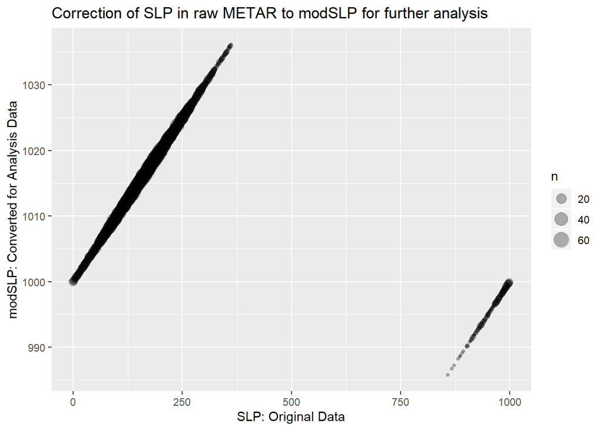

```
##
##  *** Number of NA values ***
##      METAR    WindDir  WindSpeed   WindGust      Dummy Visibility      TempC
##        133        133        133       8812        133        133        133
##       DewC  Altimeter        SLP      FahrC      dtime  origMETAR      TempF
##        133        133        133        133          0          0        133
##       DewF
##        133
##
## Visibilities after correcting for fractions:
## 0.125  0.25   0.5  0.75     1  1.25   1.5  1.75     2   2.5     3     4     5
##    13    53    51    57    50    39    55    59    91   104   168   233   242
##     6     7     8     9    10  <NA>
##   219   235   238   349  6424   132
##
##
## Counts of wind gusts extracted:
##   14   15   16   17   18   19   20   21   22   23   24   25   26   27   28   29
##    2   13   19   29   38   60   82   89   84  102   75   66   52   33   33   17
##   30   31   32   33   34   35   36   37   38   39   40   42   43   44   48   49
##   18   13    8   10    7    1    3    2    4    1    1    3    3    1    2    1
## <NA>
## 7940
```

```
##
## Issues with clouds data at records:
## # A tibble: 32 x 2
##    dtime               origMETAR
##    <dttm>              <chr>
##  1 2016-04-17 04:53:00 KGRR 170453Z AUTO A3038 RMK AO2 SLPNO 402610056 PWINO FZ~
##  2 2016-04-17 05:53:00 KGRR 170553Z AUTO A3039 RMK AO2 SLPNO 53012 PWINO FZRANO~
##  3 2016-04-17 06:53:00 KGRR 170653Z AUTO A3039 RMK AO2 SLPNO PWINO FZRANO CHINO~
##  4 2016-04-17 07:53:00 KGRR 170753Z AUTO A3039 RMK AO2 SLPNO PWINO FZRANO CHINO~
##  5 2016-04-17 08:53:00 KGRR 170853Z AUTO A3040 RMK AO2 SLPNO 53003 PWINO FZRANO~
##  6 2016-07-13 04:53:00 KGRR 130453Z AUTO A2990 RMK AO2 SLPNO PWINO CHINO RWY 8R~
##  7 2016-07-13 05:53:00 KGRR 130553Z AUTO A2990 RMK AO2 SLPNO 51010 PWINO CHINO ~
##  8 2016-07-13 06:53:00 KGRR 130653Z AUTO A2991 RMK AO2 SLPNO PWINO CHINO RWY 8R~
##  9 2016-07-13 07:53:00 KGRR 130753Z AUTO A2992 RMK AO2 SLPNO PWINO CHINO RWY 8R~
## 10 2016-07-13 08:53:00 KGRR 130853Z AUTO A2992 RMK AO2 SLPNO 51007 PWINO CHINO ~
## # ... with 22 more rows
## # A tibble: 7 x 2
##   wType     n
##   <fct> <int>
## 1 VV      106
## 2 OVC    3459
## 3 BKN    2227
## 4 SCT     752
## 5 FEW     977
## 6 CLR    1259
## 7 Error    32
##
## All Zulu times in the METAR are consistent with the datetime variable
##
## Over-writing existing file: ./RInputFiles/ProcessedMETAR/metar_kgrr_2016.rds
##
##
## Finished Processing Airport: kgrr
##
## Processing Airport: kind
## Most common 10 times for file: ./RInputFiles/metar_kind_2016.txt
## .
##  54Z  49Z  43Z  51Z  36Z  01Z  44Z  22Z  14Z  19Z
## 8767   55   54   47   45   43   42   41   40   39
##
```

[output cut: 62 more lines]

```
## Observations: 8,767
## Variables: 13
## $ METAR      <chr> "54Z 28009KT 10SM OVC015 00/M03 A3023 RMK AO2 SLP245 T00...
## $ WindDir    <chr> "280", "290", "280", "290", "300", "290", "280", "250", ...
## $ WindSpeed  <chr> "09", "08", "09", "09", "08", "08", "08", "09", "08", "1...
## $ WindGust   <chr> NA, NA, NA, NA, NA, NA, NA, NA, NA, NA, NA, NA, NA, NA, ...
## $ Dummy      <chr> " ", " ", " ", " ", " ", " ", " ", " ", " ", " ", " ", "...
## $ Visibility <chr> "10SM", "10SM", "10SM", "10SM", "10SM", "10SM", "10SM", ...
## $ TempC      <chr> "00", "00", "M01", "M01", "M01", "M01", "M01", "M01", "M...
## $ DewC       <chr> "M03", "M03", "M04", "M03", "M04", "M04", "M04", "M04", ...
## $ Altimeter  <chr> "A3023", "A3023", "A3024", "A3024", "A3023", "A3022", "A...
## $ SLP        <chr> "SLP245", "SLP244", "SLP246", "SLP246", "SLP246", "SLP24...
## $ FahrC      <chr> "T00001033", "T00001033", "T10061039", "T10061033", "T10...
## $ dtime      <dttm> 2015-12-31 00:54:00, 2015-12-31 01:54:00, 2015-12-31 02...
## $ origMETAR  <chr> "KIND 310054Z 28009KT 10SM OVC015 00/M03 A3023 RMK AO2 S...
```

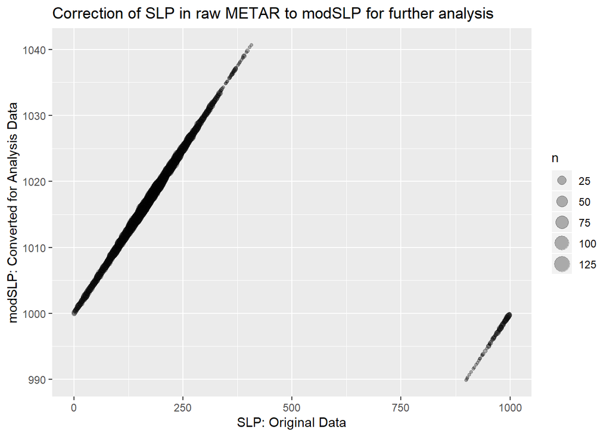

```
##
##  *** Number of NA values ***
##      METAR    WindDir  WindSpeed   WindGust      Dummy Visibility      TempC
##         10         10         10       8767         10         10         10
##       DewC  Altimeter        SLP      FahrC      dtime  origMETAR      TempF
##         10         10         10         10          0          0         10
##       DewF
##         10
##
## Visibilities after correcting for fractions:
## 0.125  0.25   0.5  0.75     1  1.25   1.5  1.75     2   2.5     3     4     5
##     5    12    24    10    18     8    19    14    66    39    84   114   161
##     6     7     8     9    10  <NA>
##   171   195   212   361  7244    10
##
##
## Counts of wind gusts extracted:
##   14   15   16   17   18   19   20   21   22   23   24   25   26   27   28   29
##    8   15   12   14   24   31   47   59   73   60   51   62   43   45   30   21
##   30   31   32   33   34   35   36   37   38   39   40   41   42   44   48 <NA>
##   21   17   17   11    5    7    4    3    4    2    2    2    3    2    2 8070
```

[figure not shown]

```
##
## wType as created from clouds data is consistent# A tibble: 6 x 2
##   wType     n
##   <fct> <int>
## 1 VV       27
## 2 OVC    2842
## 3 BKN    2243
## 4 SCT    1317
## 5 FEW    1353
## 6 CLR     985
##
## All Zulu times in the METAR are consistent with the datetime variable
##
## Over-writing existing file: ./RInputFiles/ProcessedMETAR/metar_kind_2016.rds
##
##
## Finished Processing Airport: kind
```

An issue was identified where sometimes clouds are described in the remarks. The METAR string has been modified to only pick up clouds that come prior to RMK.

There is a single issue with non-ascending cloud heights in Madison, WI. Perhaps this can be managed as a one-off or perhaps there is a need to update htChecker().

There are 100+ mis-formatted METAR for several of the cities. These appear to be data capture errors, and it is probably OK to exlude these from further analysis. The output in these situations is perhaps overly verbose (printing all is more sensible for ~10 errors rather than ~100 errors).

#### *Example #7: Updated Core Functions and Integration*

Several updates can help with the core functions and the data integration process:

- Allow for output to be cat(…, file=) to minimize the size of the .html file while maintaining the ability to see diagnostic data
- Allow for the SLP graph to be suppressed
- The core functions should return NA for anything that is an incomplete METAR (e.g., do not pull out the visibility or the wind gust if there is a fragment for that in an otherwise incomplete METAR)

The updated integration function is as follows:

```r
integrateProcessingMETAR <- function(locRawMETAR,
                                     startDay,
                                     endDay,
                                     genMET,
                                     labsMET,
                                     saveLoc=NULL,
                                     ovrWrite=FALSE,
                                     ovrWriteError=FALSE,
                                     colTypes=NULL,
                                     threshError=0.75,
                                     logFile="",
                                     ovrWriteLog=TRUE,
                                     useNAforIncomplete=FALSE,
                                     showSLPGraph=TRUE
                                     ) {

    # If the log file is to be written to, create a few details:
    if (logFile != "") {
        if (ovrWriteLog) { cat("", file=logFile, append=FALSE) }
        cat("\nProcessing for", locRawMETAR, "from", startDay, "to", endDay, "\n",
            file=logFile,
            append=TRUE
            )
    }

    # Convert startDay and endDay to date
    startDay=as.Date(startDay)
    endDay=as.Date(endDay)

    # Find the hourly reporting times, and validate that they have 'enough' data at the peak hour
    keyZulu <- findHourlyReportingTimes(metFile=locRawMETAR, threshError=threshError)

    # Use the Zulu time to create the expected minimum time and number of days
    zuluNumber <- as.numeric(str_sub(keyZulu, 1, -2))
    dtString <- paste0(as.character(startDay),
                       " 00:",
                       str_pad(as.character(zuluNumber), width=2, pad="0"),
                       ":00"
                       )

    # Read in the raw METAR file
    readFile <- readMETAR(locRawMETAR,
                          timeZ=keyZulu,
                          expMin=as.POSIXct(dtString, tz="UTC"),
                          expDays=1 + as.integer(endDay - startDay),
                          colTypes=colTypes,
                          logFile=logFile
                          )

    # Create the valMet string by pasting the key Zulu time to the front of it
    valMet <- paste0(keyZulu, genMET)

    # Make the initial pass at parsing the raw METAR file
    initFile <- initialParseMETAR(readFile,
                                  val=valMet,
                                  labs=labsMET,
                                  glimpseFinal=FALSE,
                                  logFile=logFile
                                  )

    # Convert the initially parsed METAR file
    # This process is quite hard-coded to a specific format (which is fine for now)
    convFile <- convertMETAR(initFile)

    # Fix the converted METAR file - visibility, wind gusts, SLP
    # This process is quite hard-coded to a specific format (which is fine for now)
    fixFile <- fixMETAR(convFile,
                        useNAforIncomplete=useNAforIncomplete,
                        showSLPGraph=showSLPGraph
                        )

    # Extract and wrangle the clouds from the METAR
    # This process is quite hard-coded to a specific format (which is fine for now)
    fullFile <- extractAndWrangleClouds(fixFile,
                                        metVar="origMETAR",
                                        logFile=logFile,
                                        useNAforIncomplete=useNAforIncomplete
                                        )

    # Check the time properties and add year, month (as integer and factor), day as variables
    finalFile <- checkTimeProperties(fullFile, metVar="origMETAR", timeVar="dtime")

    # If saveLoc is provided, save the file using RDS to the provided location; return it otherwise
    if (!is.null(saveLoc)) {
        if (file.exists(saveLoc)) {
            if (ovrWrite) {
                cat("\nOver-writing existing file:", saveLoc, "\n\n")
                saveRDS(finalFile, file=saveLoc)
            } else {
                cat("\nFile already exists and NOT over-written:", saveLoc, "\n\n")
                if (ovrWriteError) {
                    stop("Aborting due to ovrWriteError=TRUE\n\n")
                }
            }
        } else {
            cat("\nCreating file:", saveLoc, "\n\n")
            saveRDS(finalFile, file=saveLoc)
        }
    } else {
        return(finalFile)
    }

}
```

The base process is run for Green Bay to ensure that data outputs remain unchanges:

```r
# Run for Green Bay only yo confirm results are as expected
for (airport in c("kgrb")) {

    year <- 2016
    coreString <- paste0("metar_", airport, "_", as.character(year))

    cat("\nProcessing Airport:", airport)
    rerunGRB <- integrateProcessingMETAR(paste0("./RInputFiles/", coreString, ".txt"),
                                         startDay=paste0(as.character(year-1), "-12-31"),
                                         endDay=paste0(as.character(year+1), "-01-01"),
                                         colTypes=metType,
                                         genMET=genMET,
                                         labsMET=labsMet
                                         )
    cat("\nFinished Processing Airport:", airport, "\n")

}
```

```
##
## Processing Airport: kgrb
## Most common 10 times for file: ./RInputFiles/metar_kgrb_2016.txt
## .
##  53Z  02Z  33Z  00Z  03Z  17Z  18Z  27Z  16Z  51Z
## 8803   64   64   63   62   58   57   57   55   55
##
## The most common Zulu time for ./RInputFiles/metar_kgrb_2016.txt is 53Z
## Frequency is 77.8 % ( 8803 of 11309 )
##
## *** OBSERVATIONS EXPECTED BUT NOT RECORDED: 29 ***
##
## *** OBSERVATIONS EXPECTED BUT NOT RECORDED: ***
##
## 2016-01-06 04:53:00 UTC
## 2016-01-19 19:53:00 UTC
## 2016-01-26 07:53:00 UTC
## 2016-03-09 09:53:00 UTC
## 2016-05-06 11:53:00 UTC
## 2016-05-06 12:53:00 UTC
## 2016-05-11 08:53:00 UTC
## 2016-05-28 04:53:00 UTC
## 2016-06-17 23:53:00 UTC
## 2016-06-18 00:53:00 UTC
## 2016-06-28 12:53:00 UTC
## 2016-07-13 14:53:00 UTC
## 2016-07-13 15:53:00 UTC
## 2016-07-13 16:53:00 UTC
## 2016-07-13 17:53:00 UTC
## 2016-08-05 07:53:00 UTC
## 2016-08-31 16:53:00 UTC
## 2016-09-28 12:53:00 UTC
## 2016-10-25 01:53:00 UTC
## 2016-11-03 21:53:00 UTC
## 2016-11-15 06:53:00 UTC
## 2016-11-15 07:53:00 UTC
## 2016-11-21 00:53:00 UTC
## 2016-11-24 12:53:00 UTC
## 2016-12-03 06:53:00 UTC
## 2016-12-03 09:53:00 UTC
```

[output cut: 64 more lines]

```
## KGRB 301453Z 04016G22KT 10SM FEW010 OVC017 A3029 RMK AO2 RAE1355 SLPNO P0000 60000 53002 $
## KGRB 010253Z 04012KT 10SM SCT025 BKN031 OVC042 17/16 A3018 RMK AO2 RAB35E52 SLPNO P0000 60001 T01670156 56005
## KGRB 091753Z 10SM SCT024 SCT029 BKN033 14/07 A3042 RMK AO2 SLP304 T01390067 10139 20033 58001
## KGRB 310553Z 00000KT 10SM CLR M17/ A3020 RMK AO2 SLP236 T1172 10083 21172 401171172 56010 $
## KGRB 310653Z 00000KT 10SM CLR M17/ A3019 RMK AO2 SLP233 T1172 $
## KGRB 310753Z 00000KT 10SM CLR A3020 RMK AO2 SLPNO $
## KGRB 310853Z 23003KT 10SM CLR A3019 RMK AO2 SLPNO 50000 $
## KGRB 310953Z 17003KT 10SM BKN095 A3017 RMK AO2 SLPNO $
## KGRB 311053Z 18003KT 10SM BKN090 A3016 RMK AO2 SLPNO $
## KGRB 311953Z 16014KT 10SM SCT024 BKN110 12/08 A2994 RMK AO2 RAB41E50 SLPNO P0000 T01220078
## KGRB 312053Z 16017KT 10SM FEW023 12/08 A2991 RMK AO2 SLPNO 60000 T01220078 56038
## KGRB 312153Z 16014KT 10SM FEW110 11/07 A2987 RMK AO2 PK WND 16026/2111 RAB01E22 SLPNO P0000 T01060072
## KGRB 312253Z 16014KT 10SM CLR 11/07 A2985 RMK AO2 SLPNO T01060072
## KGRB 061853Z 21011KT 5SM BR BKN007 OVC014 03/01 A2968
## KGRB 071453Z 25017G25KT 9SM -SN OVC023 M04/M09 A2992
```

```
##
##  *** Number of NA values ***
##      METAR    WindDir  WindSpeed   WindGust      Dummy Visibility      TempC
##         62         62         62       8803         62         62         62
##       DewC  Altimeter        SLP      FahrC      dtime  origMETAR      TempF
##         62         62         62         62          0          0         62
##       DewF
##         62
##
## Visibilities after correcting for fractions:
## 0.25  0.5 0.75    1 1.25  1.5 1.75    2  2.5    3    4    5    6    7    8    9
##   41   46   28   31   35   28   24   54   66  109  143  165  158  162  169  261
##   10 <NA>
## 7223   60
##
##
## Counts of wind gusts extracted:
##   14   15   16   17   18   19   20   21   22   23   24   25   26   27   28   29
##    4   22   30   48   59   84   88   78   93   75   61   51   36   29   30    5
##   30   31   32   33   34   35   36   37   38   40   41   43   44   46 <NA>
##   21   10    3    4    3    2    2    2    4    3    1    1    1    1 7952
```

```
##
## There are 3 issues with clouds data :
##
##
## Issues with clouds data:
## 2016-09-14 17:53:00 "KGRB 141753Z VRB03KT A3031 RMK AO2 SLPNO 10194 20133 52003 RVRNO $"
## 2016-12-19 12:53:00 "KGRB 191253Z 22007KT 10SM M22/M26 A3050 RMK AO2 SLP352 T12171256"
## 2016-12-21 12:53:00 "KGRB 211253Z 20005KT 10SM M04/M07 A3006 RMK AO2 SLP189 T10391067"
##
## # A tibble: 7 x 2
##   wType     n
##   <fct> <int>
## 1 VV       73
## 2 OVC    3191
## 3 BKN     668
## 4 SCT     373
## 5 FEW     483
## 6 CLR    4012
## 7 Error     3
##
## All Zulu times in the METAR are consistent with the datetime variable
##
## Finished Processing Airport: kgrb
```

```r
# Test for equality across the files
identical(rerunGRB, fullGRB3)
```

```
## [1] TRUE
```

The process is then run for Green Bay only using the updated parameters (cat to a log file, do not show SLP graph, use NA for all values associated to a mal-formatted METAR):

```r
# Run for Green Bay only yo confirm results are as expected
for (airport in c("kgrb")) {

    year <- 2016
    coreString <- paste0("metar_", airport, "_", as.character(year))

    cat("\nProcessing Airport:", airport)
    newerGRB <- integrateProcessingMETAR(paste0("./RInputFiles/", coreString, ".txt"),
                                         startDay=paste0(as.character(year-1), "-12-31"),
                                         endDay=paste0(as.character(year+1), "-01-01"),
                                         colTypes=metType,
                                         genMET=genMET,
                                         labsMET=labsMet,
                                         logFile=paste0("./RInputFiles/ProcessedMETAR/", coreString, ".log"),
                                         useNAforIncomplete=TRUE,
                                         showSLPGraph=FALSE
                                         )
    cat("\nFinished Processing Airport:", airport, "\n")

}
```

```
##
## Processing Airport: kgrb
## Most common 10 times for file: ./RInputFiles/metar_kgrb_2016.txt
## .
##  53Z  02Z  33Z  00Z  03Z  17Z  18Z  27Z  16Z  51Z
## 8803   64   64   63   62   58   57   57   55   55
##
## The most common Zulu time for ./RInputFiles/metar_kgrb_2016.txt is 53Z
## Frequency is 77.8 % ( 8803 of 11309 )
##
## *** OBSERVATIONS EXPECTED BUT NOT RECORDED: 29 ***
##
##
## *** OBSERVATIONS RECORDED BUT NOT EXPECTED: 0 ***
##
## *** Are the extracted records unique? ***
##  TRUE
##
##
## *** Tentative Summary of Element Parsing ***
## .
## FALSE  TRUE
##    62  8741
```

```
##
##  *** Number of NA values ***
##      METAR    WindDir  WindSpeed   WindGust      Dummy Visibility      TempC
##         62         62         62       8803         62         62         62
##       DewC  Altimeter        SLP      FahrC      dtime  origMETAR      TempF
##         62         62         62         62          0          0         62
##       DewF
##         62
##
## Visibilities after correcting for fractions:
## 0.25  0.5 0.75    1 1.25  1.5 1.75    2  2.5    3    4    5    6    7    8    9
##   41   44   28   31   35   28   24   54   66  109  143  165  158  162  169  261
##   10 <NA>
## 7223   62
##
##
## Counts of wind gusts extracted:
##   14   15   16   17   18   19   20   21   22   23   24   25   26   27   28   29
##    4   22   29   48   59   83   88   78   92   74   61   50   36   29   30    5
##   30   31   32   33   34   35   36   37   38   40   41   43   44   46 <NA>
##   21   10    3    4    3    2    2    2    4    3    1    1    1    1 7957
##
##
## There are 2 issues with clouds data (see logfile):
##
## # A tibble: 7 x 2
##   wType     n
##   <fct> <int>
## 1 VV       72
## 2 OVC    3174
## 3 BKN     658
## 4 SCT     372
## 5 FEW     478
## 6 CLR    3985
## 7 Error    64
##
## All Zulu times in the METAR are consistent with the datetime variable
##
## Finished Processing Airport: kgrb
```

```r
# Check that file dimensions and variable names are the same
print(all.equal(dim(newerGRB), dim(rerunGRB)))
```

```
## [1] TRUE
```

```r
print(all.equal(names(newerGRB), names(rerunGRB)))
```

```
## [1] TRUE
```

```r
# Check that the only differences for NA are in clouds, Wind Gust, and Visibility
print(colSums(is.na(newerGRB) != is.na(rerunGRB)) %>% sort(decreasing=TRUE))
```

```
##    cLevel1    cLevel2   WindGust    cLevel3 Visibility      METAR    WindDir
##         34         14          5          5          2          0          0
##  WindSpeed      Dummy      TempC       DewC  Altimeter        SLP      FahrC
##          0          0          0          0          0          0          0
##      dtime  origMETAR      TempF       DewF     modSLP       nSKC       nCLR
##          0          0          0          0          0          0          0
##     cloud1     cType1     cloud2     cType2     cloud3     cType3     cloud4
##          0          0          0          0          0          0          0
##     cType4    cLevel4     cloud5     cType5    cLevel5     cloud6     cType6
##          0          0          0          0          0          0          0
##    cLevel6      wType       year   monthint      month        day
##          0          0          0          0          0          0
```

```r
# Check that the only differences for NA are in wType and clouds
print(colSums(!is.na(newerGRB) & !is.na(rerunGRB) & newerGRB != rerunGRB) %>% sort(decreasing=TRUE))
```

```
##      wType     cloud1     cType1       nCLR     cloud2     cType2     cloud3
##         61         34         34         27         14         14          5
##     cType3      METAR    WindDir  WindSpeed   WindGust      Dummy Visibility
##          5          0          0          0          0          0          0
##      TempC       DewC  Altimeter        SLP      FahrC      dtime  origMETAR
##          0          0          0          0          0          0          0
##      TempF       DewF     modSLP       nSKC    cLevel1    cLevel2    cLevel3
##          0          0          0          0          0          0          0
##     cloud4     cType4    cLevel4     cloud5     cType5    cLevel5     cloud6
##          0          0          0          0          0          0          0
##     cType6    cLevel6       year   monthint      month        day
##          0          0          0          0          0          0
```

And the process can then be run for the Chicago 2015-2016-2017 data:

```r
# Run for each of the 6 airports and save the processed file
for (year in 2015:2017) {

    airport <- "kord"
    coreString <- paste0("metar_", airport, "_", as.character(year))

    cat("\nProcessing Airport:", airport, "Year:", year)
    integrateProcessingMETAR(paste0("./RInputFiles/", coreString, ".txt"),
                             startDay=paste0(as.character(year-1), "-12-31"),
                             endDay=paste0(as.character(year+1), "-01-01"),
                             colTypes=metType,
                             genMET=genMET,
                             labsMET=labsMet,
                             saveLoc=paste0("./RInputFiles/ProcessedMETAR/", coreString, ".rds"),
                             ovrWrite=TRUE,
                             logFile=paste0("./RInputFiles/ProcessedMETAR/", coreString, ".log"),
                             useNAforIncomplete=TRUE,
                             showSLPGraph=FALSE
                             )
    cat("\nFinished Processing Airport:", airport, "Year:", year, "\n")

}
```

```
##
## Processing Airport: kord Year: 2015
## Most common 10 times for file: ./RInputFiles/metar_kord_2015.txt
## .
##  51Z  23Z  26Z  24Z  38Z  02Z  06Z  33Z  07Z  29Z
## 8776   53   53   52   52   51   51   51   49   48
##
## The most common Zulu time for ./RInputFiles/metar_kord_2015.txt is 51Z
## Frequency is 79.8 % ( 8776 of 10997 )
##
## *** OBSERVATIONS EXPECTED BUT NOT RECORDED: 32 ***
##
##
## *** OBSERVATIONS RECORDED BUT NOT EXPECTED: 0 ***
##
## *** Are the extracted records unique? ***
##  TRUE
##
##
## *** Tentative Summary of Element Parsing ***
## .
## FALSE  TRUE
##     8  8768
```

```
##
##  *** Number of NA values ***
##      METAR    WindDir  WindSpeed   WindGust      Dummy Visibility      TempC
##          8          8          8       8776          8          8          8
##       DewC  Altimeter        SLP      FahrC      dtime  origMETAR      TempF
##          8          8          8          8          0          0          8
##       DewF
##          8
##
## Visibilities after correcting for fractions:
## 0.125  0.25   0.5  0.75     1  1.25   1.5  1.75     2   2.5     3     4     5
##     9    40    59    42    32    24    57    22    88    70   123   136   161
##     6     7     8     9    10  <NA>
##   171   192   240   312  6990     8
##
##
## Counts of wind gusts extracted:
##   14   15   16   17   18   19   20   21   22   23   24   25   26   27   28   29
##    6   16   32   51   74  111  135  123  142  122  109   95   71   76   54   51
##   30   31   32   33   34   35   36   37   38   39   41   43   45 <NA>
##   32   19   17   17    8    3   10    6    5    1    1    1    1 7387
##
##
## wType as created from clouds data is consistent
## # A tibble: 7 x 2
##   wType     n
##   <fct> <int>
## 1 VV       71
## 2 OVC    3343
## 3 BKN    2040
## 4 SCT     961
## 5 FEW    1403
## 6 CLR     950
## 7 Error     8
##
## All Zulu times in the METAR are consistent with the datetime variable
##
## Over-writing existing file: ./RInputFiles/ProcessedMETAR/metar_kord_2015.rds
##
##
```

[output cut: 9 more lines]

```
## Frequency is 81.6 % ( 8815 of 10809 )
##
## *** OBSERVATIONS EXPECTED BUT NOT RECORDED: 17 ***
##
##
## *** OBSERVATIONS RECORDED BUT NOT EXPECTED: 0 ***
##
## *** Are the extracted records unique? ***
##  TRUE
##
##
## *** Tentative Summary of Element Parsing ***
## .
## FALSE  TRUE
##    10  8805
```

```
##
##  *** Number of NA values ***
##      METAR    WindDir  WindSpeed   WindGust      Dummy Visibility      TempC
##         10         10         10       8815         10         10         10
##       DewC  Altimeter        SLP      FahrC      dtime  origMETAR      TempF
##         10         10         10         10          0          0         10
##       DewF
##         10
##
## Visibilities after correcting for fractions:
##     0 0.125  0.25   0.5  0.75     1  1.25   1.5  1.75     2   2.5     3     4
##     3     8    22    21    19    27    22    34    30    64    54    99   108
##     5     6     7     8     9    10  <NA>
##   168   169   179   184   284  7310    10
##
##
## Counts of wind gusts extracted:
##   14   15   16   17   18   19   20   21   22   23   24   25   26   27   28   29
##    5   10   39   44   80  119  109  132  127   97   88   84   71   46   36   30
##   30   31   32   33   34   35   36   37   38   39   40   41   42   43   44   45
##   27   18   19   15    9    5    3    3    3    2    3    1    1    1    2    2
##   46   52   54 <NA>
##    2    1    1 7580
##
##
## There are 1 issues with clouds data (see logfile):
##
## # A tibble: 7 x 2
##   wType     n
##   <fct> <int>
## 1 VV       55
## 2 OVC    3179
## 3 BKN    2205
## 4 SCT    1066
## 5 FEW    1487
## 6 CLR     812
## 7 Error    11
##
## All Zulu times in the METAR are consistent with the datetime variable
##
```

[output cut: 12 more lines]

```
## Frequency is 80.9 % ( 8788 of 10864 )
##
## *** OBSERVATIONS EXPECTED BUT NOT RECORDED: 20 ***
##
##
## *** OBSERVATIONS RECORDED BUT NOT EXPECTED: 0 ***
##
## *** Are the extracted records unique? ***
##  TRUE
##
##
## *** Tentative Summary of Element Parsing ***
## .
## FALSE  TRUE
##    11  8777
```

```
##
##  *** Number of NA values ***
##      METAR    WindDir  WindSpeed   WindGust      Dummy Visibility      TempC
##         11         11         11       8788         11         11         11
##       DewC  Altimeter        SLP      FahrC      dtime  origMETAR      TempF
##         11         11         11         11          0          0         11
##       DewF
##         11
##
## Visibilities after correcting for fractions:
## 0.125  0.25   0.5  0.75     1  1.25   1.5  1.75     2   2.5     3     4     5
##     1    20    33    20    29    16    44    30    55    59   111   123   163
##     6     7     8     9    10  <NA>
##   154   137   207   228  7347    11
##
##
## Counts of wind gusts extracted:
##   14   15   16   17   18   19   20   21   22   23   24   25   26   27   28   29
##   13   18   35   62   91  121  139  162  155  139   96   74   52   57   49   39
##   30   31   32   33   34   35   36   37   38   39   40   42   43   45   46   48
##   34   26   11   20   11    9    3    9    1    7    5    2    3    1    1    1
## <NA>
## 7342
##
##
## wType as created from clouds data is consistent
## # A tibble: 7 x 2
##   wType     n
##   <fct> <int>
## 1 VV       31
## 2 OVC    3342
## 3 BKN    2126
## 4 SCT    1006
## 5 FEW    1507
## 6 CLR     765
## 7 Error    11
##
## All Zulu times in the METAR are consistent with the datetime variable
##
## Over-writing existing file: ./RInputFiles/ProcessedMETAR/metar_kord_2017.rds
##
##
## Finished Processing Airport: kord Year: 2017
```